# Appendix 4: Documentation of Code

Max Harleman, Chris Moloney, Minbae Lee, Dan Kardish, Andrew Morgan

April 8, 2019; Updated July - August 2021 by Andrew Morgan

# Brief Introduction and Summary:

This file is a compilation of various statistical learning methods we (Max Harleman, Chris Moloney, Minbae Lee, Dan Kardish, Andrew Morgan) performed as a group on the CATO Human Freedom Index that measures human freedom throughout the world on a country-level. This analysis was completed for Statistical Learning course at the University of Pittsburgh in the Spring of 2019. The project had several parts including finding the dataset, performing various methods (as shown in this markdown file), the conclusions of findings (this markdown file and report we wrote as individuals), and a group presentation. We recommend only reading through (or downloading the R-Markdown file) if you are interested in the details of the methods performed or the code we wrote.

The **primary** task of the project was to use real data and various statistical methods learned in class to demonstrate the pros and cons each method possesses. The class had a heavy focus on the concept of the bias-variance tradeoff. Meaning some models may capture less variance by being more biased than others (like multiple linear regression). Or models may capture a lot of variance, but have very little bias (random forests or neural networks). High bias tends to allow for more inferencing to analyze the effects of specific predictors. High variance tends to fit the data better (guaranteed on training set), however the accuracy may falter if the model is overfit (big issue with high-variance models like neural networks). The methods used are multiple linear regression (MLR), bootstrapping (primarily cross-validation), polynomial regression, splines, GAMs (Generalized Additive Models), KNN regression, decision trees, random forest (bagging), boosting. Some other models not seen here are related to classification (our dataset is a regression problem) like linear discriminant analysis (LDA) and quadratic discriminant analysis (QDA).

The **secondary** task of the project is to determine the most significant predictors of human freedom. The dataset is large (39 predictors, and 1305 observations after data tidying). By determining the most significant predictors, we should have a better grasp of what determines human freedom. Then, we will create a smaller model (~10 predictors) to try and capture the greatest amount of variance possible within the dataset. If this smaller model is relatively close to the most accurate models, we can assert that the human freedom index could be simplified. An important note here is that this task is largely based around **inferenceing** which some models perform better than others. The models that have better inferencing tend to have biased models to allow for these inferences (again like multiple linear regression). Hence, some models could more accurate, but due to limited inferencing to determine those significant predictors, we may decide to not focus on that model (unless the accuracy is significantly better than the preferred model).

#### Another Note: We decided on using a random seed to get consistent results for our analysis. Obviously this will bias the dataset, so we chose the number ‘111’ as the seed value at the begining of the analysis before using any methods. This number was randomly chosen, and will constantly appear with the comman ‘set.seed(111)’ at the start of many code chunks.

# Andrew’s Website Changes

In the Summer of 2021, I (Andrew), have modified the project in certain ways including the Markdown file and the Rendered PDF and HTML files.

## Changelog

The Goal: Get the project into a state I am proud of and displays some of my statistical learning skills.

Overall the changes are made as an improvement over the existing code. Most of the code was initially written by Max and Myself (Andrew), as we had the most programming experience of the group. **I believe Max Harleman’s work on the project was incredible and much credit for this code needs to go to him!**

- Primary reason for the alterations is to reacquaint myself with the project, dataset, and packages used.
- Secondary reason for the changes are to improve the visualizations for my written summary about this project’s findings.
- Tertiary reason for the changes is some large errors were found and refactoring was desired due to inconsistent naming, syntax, spacing.
- **Fixed the major Error.** The test set not being held out from training some models. Often we seemed to use the combined (train + test) for cross-validation to find the better estimate of the MSE. Then, we take the best cross-validated model and test it against the test set (but it was trained on that data as well), making some conclusions very wrong. Luckily, the findings are not really affected by this potentially catastrophic error.
- Improvements to graphs and visualizations. I improved the descriptions (labels and points) within the graphs and added new graphs as visualizations for my written post on my website.
- Many of my changes result in more time, memory, and resource consumption. This is unfortunate, but I believe the results are now more robust and less biased.
- Refactoring: I revised the code to have better style, syntax, and flexibility. Additionally, some errors were discovered that we missed over 2 years ago.
- Restructure and Reorganized: I reorganized the code to be more concise and explicit about tasks and methods used. Additionally, some code was rearranged to be in a more logical spot in terms of part of the analysis it should/had been performed.
- Areas Expanded: Non-linear section with polynomial regression, splines, and GAMS were improved to test more models than there were initially. The Findings do not seem to change the final conclusions much (the models are significantly more accurate, but still not preferable to the MLR models).
- Areas with Major Refactoring: I improved the multiple linear regression section (more analysis of best models found), tree-based methods (decision trees, random forests, boosting; focus on the most important predictors within models),
- A larger focus in conclusion about our “Final” model(s). I create a final models using the predictors we isolated as most significant (I added some additional as I believe we missed some. The models used in this section were MLR, MLR with polynomial terms, Random Forest, and Boosting.

# 1. Data Cleaning and Setup:

## 1.1 Load the Libraries

# 1.2

The following Code aims to load, tidy, and format the data and resulting dataframe into a state that can be easily manipulated, altered, and used for the following methods. The goals are as follows:

- Many variables are related and explain the same thing as aggregates for more specific metrics already captured. For example, there is a predictor that measures the amount of personal freedom with respect to the rule-of-law of the land that is an average (or aggregate) of more specific predictors like security, protection of private property, safety for citizens from murder or kidnappings. We remove the aggregate, while including the specific predictors.
- We remove columns with a large number of NAs. This is far from ideal, but we have no good way of estimating these values. These columns that are removed, frankly are not terribly important, and were only added to the dataset in more recent years.
- We tested the dataset for leverage points and outliers. We found and removed these observations using code found here: https://stats.stackexchange.com/questions/164099/removing-outliers-based-on-cooks-distance-in-r-language/345040.
- Now we need to convert the data to a dataframe ready for analysis. This dataframe then needs to be split into a train and test set (80:20). The train and test sets are used for getting a more accurate and less biased estimate of the MSE (mean-squared error) from our models.

```r
################################   GET DATA READY   ###########################

#######  THE FILE LOCATION MAY NOT BE RIGHT, YOU NEED TO CORRECT IT  ##########
# Read in the dataset
hfi_data = read.csv(file = "C:/GitHub/Private-Projects/School/2019-Spring/STAT - Statistical Learning and Data Science/Project/Actual project/the-human-freedom-index/hfi_cc_2018.csv")##
###############################################################################


## Creating a county by year row names as the new 'identifier' or primary key
country= hfi_data$countries
year= hfi_data$year
co_year= paste(country, year, sep = " ", collapse = NULL)
hfi_data= data.frame(co_year, hfi_data)
hfi_data$ISO_code <- NULL
hfi_data$countries <- NULL
hfi_data$region <- NULL
hfi_data$year <- NULL
rownames(hfi_data)=hfi_data[,1]
hfi_data$co_year <- NULL

# Get the # columns and # rows before removing the columns and rows with N/A's
# nrow(hfi_data)
# ncol(hfi_data)

# Start adding columns/variables to remove.
# These vars are aggragates of other variables listed, and therefore we remove.
cols_to_remove = c("pf_rol", "pf_ss", "pf_movement", "pf_ss_women", "pf_religion",
                   "pf_association", "pf_expression", "pf_identity", "pf_score", "pf_rank",
                   "ef_government", "ef_legal", "ef_money", "ef_trade", "ef_regulation",
                   "ef_score", "ef_rank", "pf_identity_sex", "ef_trade_movement",
                   "pf_ss_disappearances", "ef_regulation_labor", "ef_regulation_business")
hfi_data = hfi_data %>% dplyr::select(-cols_to_remove)

# Second batch of columns to remove
# This finds columns with less consistent values for a given country
# Remove if there are many (100+) N/A's for a given variable/predictor
cols_to_remove = list()
list_counter = 1
for (i in 1:ncol(hfi_data)){
  # checking if the number of N/A's is 100 or more
  if(sum(is.na(hfi_data[,i])) >= 100 ){
    # append the column name that has 100+ N/A's
    cols_to_remove[[list_counter]] = colnames(hfi_data[i])
    list_counter = list_counter + 1     # update the counter
  }
}
cols_to_remove = unlist(cols_to_remove)  # creates a vector to use with dyplr
hfi_data = hfi_data %>% dplyr::select(-cols_to_remove)

# After removing the columns producing significant number of N/A's
# Remove all observations that still have miscellaneous N/A's
hfi_data = hfi_data %>% na.omit()

# Get the # columns and # rows after removing dimensions and observations
# nrow(hfi_data)
# ncol(hfi_data)

# the list of columns that relate to human freedom score (the response) to ignore
responses = c("hf_rank", "hf_quartile")
hfi_data_features = hfi_data %>% dplyr::select(-(c(responses, "hf_score")))
hfi_data_combined = hfi_data %>% dplyr::select(-responses)

# Get the # columns and # rows after removing dimensions and observations
# nrow(hfi_data)
# ncol(hfi_data)

# simply used to get same results regardless of run. Methods should be robust to the seed changing, though
set.seed(111)

# create the Training and Testing Set
hfi_data_combined_train = hfi_data_combined %>% sample_frac(size = .8)
hfi_data_combined_test = hfi_data_combined %>% setdiff(hfi_data_combined_train)

# get the Mean-TSS of the Training and Testing Sets; Use for judging effectiveness
mean_tss_combined = mean((mean(hfi_data_combined$hf_score) - hfi_data_combined$hf_score)^2)
mean_tss_train = mean((mean(hfi_data_combined_train$hf_score) - hfi_data_combined_train$hf_score)^2)
mean_tss_test = mean((mean(hfi_data_combined_test$hf_score) - hfi_data_combined_test$hf_score)^2)
```

The most important takeaway is the estimates for Mean Total Sums Squared (mean TSS). These values represent the expected variance using just the average human freedom score (the response) instead of a more complex model (it is simply an intercept = mean(hf_score)). The point is to see how much more variance is explained from other models using the resulting Mean Squared Error (MSE). However, the MSE is averaged, so we take the average of the TSS to result in the mean TSS in order to have comparable values. The Mean TSS is primarily used to judge a model’s test MSE (the MSE from a model on NEW data the model has never seen).

- Mean TSS for all the observations (combined test and train dataset): 0.9762658
- Mean TSS for all the *training* observations: 0.9995088
- Mean TSS for all the *testing* observations: 0.882886 (the most important one to compare models’ MSEs)

# 2. Exploratory Analysis

## Create a Correlation Matrix with Permutation Testing

The first exploratory analysis will be to create a correlation matrix to analyze how linearly correlated the features of the dataset are. The primary focus will be on the Human Freedom Score (hf_score) that measures human freedom within a given country. The hf_score will be located on the very first row of the matrix (first element) and the far right column (last element in columns). The matrix is split into 2 different measurements:

- Top-Left of the matrix is the permutation testing results. Permutation testing uses bootstrap-like techniques to get a better estimate of the correlation. If there is a black dot for a row, column pair, that means the pair of features are significantly correlated (most likely not a correlation of 0).
- Bottom-Right of the matrix is the correlation values in different shades of red/orange and blue. The more red a row, column feature pair is, the more positively, linearly correlated the features are; the more blue indicates that there is a negatively, linearly correlated feature pair.
- The diagonal from top-right to bottom-left is the correlation of the same predictors (so the correlation of hf_score and hf_score, or pf_ss_homicide and pf_ss_homicide). These correlation values will always be +1 (dark red). These values should be ignored.

```r
##############  CORRELATION WITH 'hf_score' RESPONSE   ####################
# Get all correlations (will use the rest later for a correlation matrix)
actual_correlation_matrix = cor(x = hfi_data_combined)
hf_score_correlations = actual_correlation_matrix['hf_score', ]

# This sorts the ACTUAL and MAGNITUDE of correlations
actual_sorted_hf_score_correlations = sort(hf_score_correlations, decreasing = TRUE)
abs_sorted_hf_score_correlations = sort(abs(hf_score_correlations), decreasing = TRUE)

head(actual_sorted_hf_score_correlations, 10)
```

```
##                       hf_score          pf_expression_control
##                      1.0000000                      0.7586429
##        pf_expression_influence              ef_legal_military
##                      0.7457798                      0.7308047
##            ef_trade_regulatory ef_trade_regulatory_compliance
##                      0.7073884                      0.6632339
##                ef_legal_gender          ef_trade_tariffs_mean
##                      0.6104228                      0.6017655
##           pf_movement_domestic                    ef_money_sd
##                      0.5561843                      0.5466009
```

```r
tail(actual_sorted_hf_score_correlations, 4)
```

```
##    pf_religion_harassment       ef_trade_tariffs_sd ef_regulation_labor_hours
##                0.10589262                0.06847924                0.06347336
## ef_government_consumption
##               -0.32431183
```

```r
head(abs_sorted_hf_score_correlations, 10)
```

```
##                       hf_score          pf_expression_control
##                      1.0000000                      0.7586429
##        pf_expression_influence              ef_legal_military
##                      0.7457798                      0.7308047
##            ef_trade_regulatory ef_trade_regulatory_compliance
##                      0.7073884                      0.6632339
##                ef_legal_gender          ef_trade_tariffs_mean
##                      0.6104228                      0.6017655
##           pf_movement_domestic                    ef_money_sd
##                      0.5561843                      0.5466009
```

```r
###############    Correlation Matrix Testing    #####################
# Using Bootstrap Testing/Estimating to estimate Correlation throughout dataset
# Useful for finding insights to how correlated data is with a more robust
#     correlation estimate
nperms = 100 # smaller number of permutations to speed up processing
significance_level = 0.02  # better with the smaller nperms

nperms = 1000  # a larger number, slow process
significance_level = 0.005  # better with the larger nperms
permutation_upper_estimate = data.frame(matrix(NA ,
                                             ncol = ncol(hfi_data_combined),
                                             nrow = ncol(hfi_data_combined)),
                                      row.names = rownames(actual_correlation_matrix))
colnames(permutation_upper_estimate) = colnames(actual_correlation_matrix)

permutation_lower_estimate = data.frame(matrix(NA ,
                                             ncol = ncol(hfi_data_combined),
                                             nrow = ncol(hfi_data_combined)),
                                      row.names = rownames(actual_correlation_matrix))
colnames(permutation_lower_estimate) = colnames(actual_correlation_matrix)


for ( i in 1:ncol(actual_correlation_matrix)){
  for( j in 1:nrow(actual_correlation_matrix)){
    if( i > j){
      i_name = rownames(actual_correlation_matrix)[i]
      j_name = rownames(actual_correlation_matrix)[i]
      # ONLY do half the matrix
      permutation_vector = rep(-10, nperms)
      for (k in 1:nperms) {
        suffle_i = sample(x = hfi_data_combined[, i_name],
                          size = nrow(hfi_data_combined),
                          replace = FALSE)
        permutation_vector[k] = cor(suffle_i, hfi_data_combined[, j_name])
      }
      permutation_lower_estimate[i,j] = quantile(permutation_vector, significance_level)
      permutation_upper_estimate[i,j] = quantile(permutation_vector, 1-significance_level)
    } else if (i == j){
      # correlation of X an X is ALWAYS == 1
      permutation_lower_estimate[i,j] = 1
      permutation_upper_estimate[i,j] = 1
    }
  }
}

# These functions get the Upper and Lower 'Triangles' of a correlation matrix
get_upper_tri <- function(cormat){
  cormat[lower.tri(cormat)]<- NA
  return(cormat)
}

get_lower_tri<-function(cormat){
  cormat[upper.tri(cormat)] <- NA
  return(cormat)
}

# Get All pairs of Vars that are significant via permutation testing
is_significant = matrix(NA , ncol = ncol(hfi_data_combined),
                        nrow = ncol(hfi_data_combined),
                        dimnames = list(c(colnames(hfi_data_combined)),
                                        c(colnames(hfi_data_combined))))
total = 0
count = 0
col_names = colnames(hfi_data_combined)
for ( i in 1:ncol(hfi_data_combined)){
  for( j in 1:ncol(hfi_data_combined)){
    if( i > j){
      total = total + 1
      if( permutation_lower_estimate[i,j] <= actual_correlation_matrix[i,j] &
          actual_correlation_matrix[i,j] <= permutation_upper_estimate[i,j] ){
        is_significant[i, j] = NA  # this will remove the 'FALSE' values later
      } else{
        is_significant[i,j] = TRUE
        count = count + 1
      }
    }
  }
}

rownames(is_significant)
```

```
##  [1] "pf_ss_homicide"                    "pf_ss_disappearances_disap"
##  [3] "pf_ss_disappearances_violent"      "pf_ss_disappearances_fatalities"
##  [5] "pf_ss_disappearances_injuries"     "pf_movement_domestic"
##  [7] "pf_movement_foreign"               "pf_religion_harassment"
##  [9] "pf_religion_restrictions"          "pf_expression_killed"
## [11] "pf_expression_jailed"              "pf_expression_influence"
## [13] "pf_expression_control"             "pf_identity_sex_male"
## [15] "pf_identity_sex_female"            "ef_government_consumption"
## [17] "ef_legal_courts"                   "ef_legal_military"
## [19] "ef_legal_enforcement"              "ef_legal_gender"
## [21] "ef_money_growth"                   "ef_money_sd"
## [23] "ef_money_inflation"                "ef_money_currency"
## [25] "ef_trade_tariffs_mean"             "ef_trade_tariffs_sd"
## [27] "ef_trade_tariffs"                  "ef_trade_regulatory_compliance"
## [29] "ef_trade_regulatory"               "ef_trade_black"
## [31] "ef_trade_movement_capital"         "ef_trade_movement_visit"
## [33] "ef_regulation_credit_private"      "ef_regulation_credit"
## [35] "ef_regulation_labor_minwage"       "ef_regulation_labor_hours"
## [37] "ef_regulation_labor_conscription"  "ef_regulation_business_start"
## [39] "ef_regulation_business_compliance" "hf_score"
```

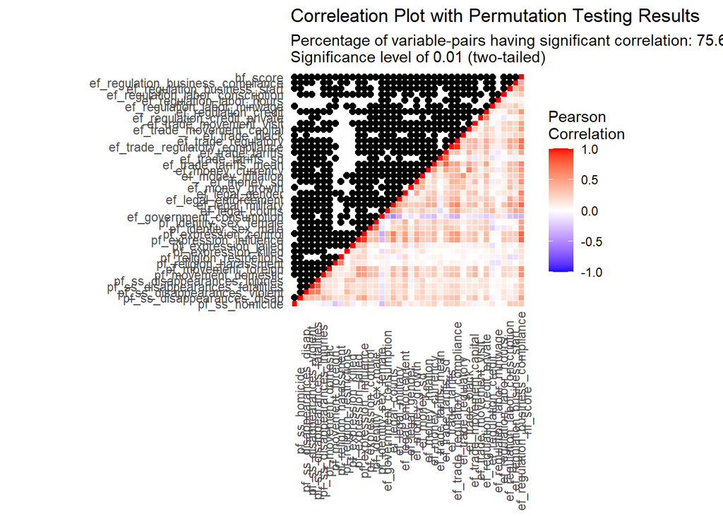

```r
# Now to Combine into 1 dataframe
upper_triangle = get_upper_tri(actual_correlation_matrix)
lower_triangle = get_lower_tri(is_significant)

melted_upper = melt(upper_triangle, na.rm = TRUE)
melted_lower = melt(lower_triangle, na.rm = TRUE)
colnames(melted_lower)[3] = "IsSignificant"

graph_df = melted_upper %>%full_join(melted_lower)
graph_df$IsSignificant = as.factor(as.character(graph_df$IsSignificant))
graph_df_final = graph_df %>% mutate(value = ifelse(is.na(value), 0, value))

# Graph the Dataframe!
ggplot(data = graph_df_final, aes(Var2, Var1, fill = value)) +
  geom_tile(color = "white") +
  geom_point(aes(shape = IsSignificant, fill=value), size=2 ) +
  scale_fill_gradient2(low = "blue", high = "red", mid = "white",
                       midpoint = 0, limit = c(-1,1), space = "Lab",
                       name="Pearson\nCorrelation") +
  theme_minimal() +
  scale_shape(guide = 'none') +
  theme(
    axis.title.x = element_blank(),
    axis.title.y = element_blank(),
    panel.grid.major = element_blank(),
    panel.border = element_blank(),
    panel.background = element_blank(),
    axis.text.x = element_text(angle = 90),
  ) +
  coord_fixed() +
  ggtitle("Correleation Plot with Permutation Testing Results",
          subtitle = paste0("Percentage of variable-pairs having significant correlation: ",
                            ((round((count/total),3)) * 100),
                            "%\nSignificance level of ", significance_level*2, " (two-tailed)"))
```

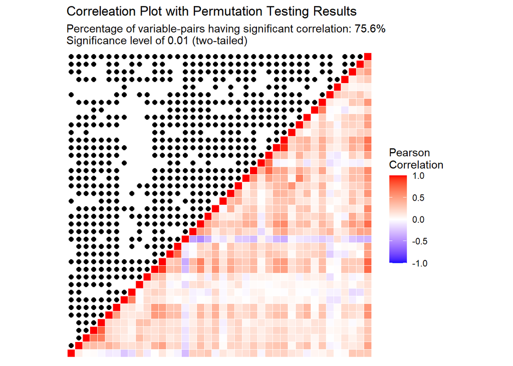

```r
# Graph the Dataframe! with no VARNAMES!
ggplot(data = graph_df_final, aes(Var2, Var1, fill = value)) +
  geom_tile(color = "white") +
  geom_point(aes(shape = IsSignificant, fill=value), size=2 ) +
  scale_fill_gradient2(low = "blue", high = "red", mid = "white",
                       midpoint = 0, limit = c(-1,1), space = "Lab",
                       name="Pearson\nCorrelation") +
  theme_minimal() +
  scale_shape(guide = 'none') +
  theme(
    axis.title.x = element_blank(),
    axis.title.y = element_blank(),
    panel.grid.major = element_blank(),
    panel.border = element_blank(),
    panel.background = element_blank(),
    axis.text.x = element_blank(),
    axis.text.y = element_blank()
  ) +
  coord_fixed() +
  ggtitle("Correleation Plot with Permutation Testing Results",
          subtitle = paste0("Percentage of variable-pairs having significant correlation: ",
                            ((round((count/total),3)) * 100),
                            "%\nSignificance level of ", significance_level*2, " (two-tailed)"))
```

```r
# This is SUPER HIGH Correlation
actual_correlation_matrix['ef_trade_regulatory',
                          'ef_trade_regulatory_compliance']
```

```
## [1] 0.9452313
```

At a glance, the color scheme indicates a lot of red, meaning many predictors are positively, linearly correlated with each other. Additionally, there are many black dots meaning almost all feature pairs are correlated with a 99% accuracy based on permutation testing. The hf_score (measuring the human freedom variable) is found on the first row (very top of matrix) and last column (far right of matrix). All but 1 variable seems to have correlation with hf_score. This finding indicates the multiple linear regression technique may yield very useful and accurate predictions.

The variables ef_trade_regulatory and ef_trade_regulatory_compliance are heavily correlated predictors. This does not surprise us as one deals with how harsh regulations are to businesses and the other is how strictly the country follows through. The countries with lenient policies will tend to have lacking enforcement, while heavily regulated economies will have their governments cracking down on companies breaking regulations.

This is an example of the significant correlation between the predictors within the dataset. This finding indicates the human freedom index can probably be measured will minimal loss in accuracy with fewer predictors. Additionally, the correlation may indicate confounding predictors. Confounding predictors are predictors that capture the same variance as the predictors themselves are heavily correlated (like ef_trade_regulatory and ef_trade_regulatory_compliance). These confounding variables are known to not improve model accuracy significantly if 1 exists within the model already.

# 3. Linear Regression and Model Selection Methods:

## 3.1 Best-Subset Model Selection

The MLR selection technique to select the best model. We exhaustively look through all the permutations of the predictors with best-subset, and select the best model for each x-predictor subset. **This section takes time.**

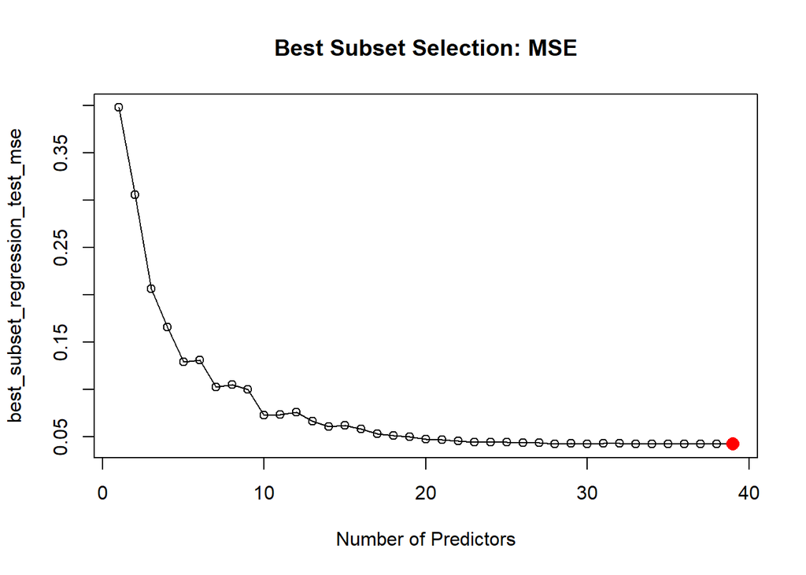

```
## integer(0)
```

```r
# Best-Subset
set.seed(111)
max_predictors_best_subset = 39   # set to max; can alter if takes too long
# This trains *all* possible permutations for MLR of the data
best_subset_regression = regsubsets(hf_score ~ ., data = hfi_data_combined_train,
                                    method = "exhaustive",
                                    nvmax = max_predictors_best_subset, intercept = TRUE)
result = summary(best_subset_regression)

# Now to find the Test Errors to judge which model is best!
# Doing Generic MSE and AIC to penalize extra terms/predictors more
best_subset_regression_test_mse = rep(-1, max_predictors_best_subset)
best_subset_regression_test_aic = rep(-1, max_predictors_best_subset)

for (i in 1:max_predictors_best_subset){
  coef_i = coef(best_subset_regression, id = i)
  yhat_temp = as.matrix(
    hfi_data_combined_test[,colnames(hfi_data_combined_test) %in% names(coef_i)] ) %*%
    coef_i[names(coef_i) %in% colnames(hfi_data_combined_test)]
  yhat = as.vector(yhat_temp) + coef_i["(Intercept)"]
  # MSE = RSS / N (Average of Residuals)
  best_subset_regression_test_mse[i] = mean((yhat- hfi_data_combined_test$hf_score )^2)

  # AIC = 2*P + N * LOG(RSS/N) === 2*P + N * LOG(MSE)
  # P = # predictors; N = number of obs in test set
  best_subset_regression_test_aic[i] = 2*i +
    nrow(hfi_data_combined_test) * log(best_subset_regression_test_mse[i], base = 10)
}

# plot the regular MSE With highlighted min. point
plot(best_subset_regression_test_mse, main = "Best Subset Selection: MSE",
     xlab = 'Number of Predictors') +
  lines(x = 1:max_predictors_best_subset, y=best_subset_regression_test_mse) +
  points(x=which.min(best_subset_regression_test_mse),
         y=best_subset_regression_test_mse[which.min(best_subset_regression_test_mse)],
         col = "red", pch = 16, cex = 1.5)
```

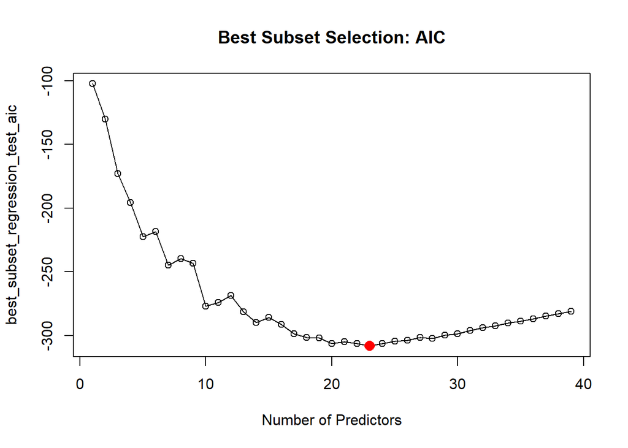

```
## integer(0)
```

```r
# plot the AIC results With highlighted min. point
plot(best_subset_regression_test_aic, main = "Best Subset Selection: AIC",
     xlab = 'Number of Predictors') +
  lines(x = 1:max_predictors_best_subset, y=best_subset_regression_test_aic) +
  points(x=which.min(best_subset_regression_test_aic),
         y=best_subset_regression_test_aic[which.min(best_subset_regression_test_aic)],
         col = "red", pch = 16, cex = 1.5)
```

```r
best_subset_regression_test_mse[which.min(best_subset_regression_test_mse)]
```

```
## [1] 0.04212529
```

```r
best_subset_regression_test_aic[which.min(best_subset_regression_test_aic)]
```

```
## [1] -308.0917
```

```r
which.min(best_subset_regression_test_mse)  # Number of Predictors with Best MSE
```

```
## [1] 39
```

```r
which.min(best_subset_regression_test_aic)  # Number of Predictors with Best AIC
```

```
## [1] 23
```

The best-subset model results in 2 different findings. We did a default best-subset selection and an AIC (penalizing larger, more complex models).

The default best-subset result indicates that all 39 predictors are needed to maximize accuracy. However, one needs to be cautious as the benefit of adding more than ~15 predictors seems to decline. The AIC model selection penalizes these larger models that inherently can predict more variance with the higher degrees of freedom. The AIC model is probably the better model as it is 23 number of predictors (less than the default).

## 3.2 Backward Deletion and Forward Selection

To be honest, after the best-subset, these selection methods are more for our interest and intrigue. We completed these before best-subset initially (as best-subset takes a lot of time to run exhaustively). Therefore, we left these models in. We use the AIC to again penalize models that have many predictors.

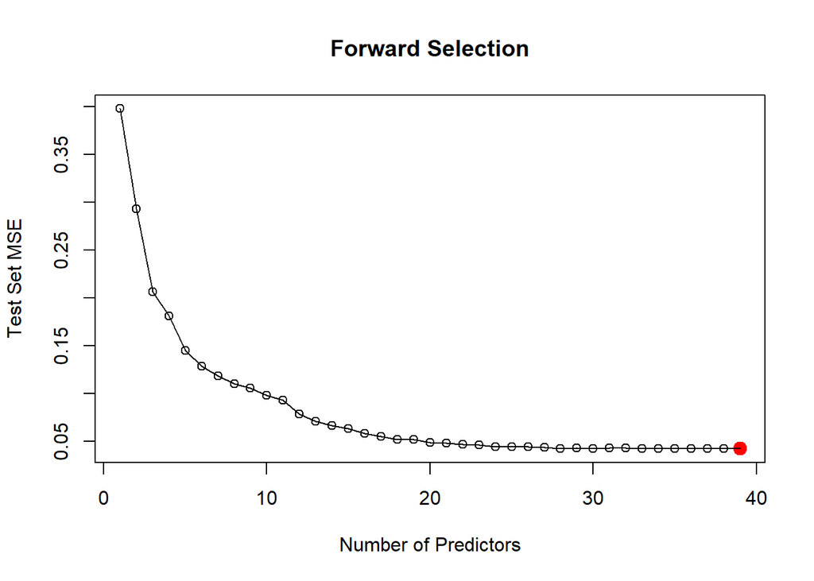

```
## integer(0)
```

```r
set.seed(111)


# Forward Selection MLR Method
forward_regression = regsubsets(hf_score ~ ., method = "forward",
                                nvmax = (ncol(hfi_data_combined_train)-1),
                                data = hfi_data_combined_train)
# create test model matrix to easily create the predictions
forward_regression_model_matrix = model.matrix(hf_score ~ ., data = hfi_data_combined_test)
# store MSE and AIC results for the test set
forward_regression_test_mse = rep(-1, (ncol(hfi_data_combined_train)-1))
forward_regression_test_aic = rep(-1, (ncol(hfi_data_combined_train)-1))

for( i in 1:(ncol(hfi_data_combined_train)-1)){
  # AGAIN, using pipes to efficiently create predictions
  coef_i = coef(forward_regression, id = i)
  preds = forward_regression_model_matrix[,names(coef_i)] %*% coef_i
  # create the MSE and then AIC
  forward_regression_test_mse[i] = mean((preds - hfi_data_combined_test$hf_score)^2)
  forward_regression_test_aic[i] = 2*length(coef_i) +
    (nrow(hfi_data_combined_test))*log(forward_regression_test_mse[i], base = 10)
}

# Plot the MSE and AIC results with the minimum point highlighted
plot(x = 1:(ncol(hfi_data_combined_train)-1), y = forward_regression_test_mse,
     main = "Forward Selection", ylab = "Test Set MSE",
     xlab = "Number of Predictors") +
  points(x = which.min(forward_regression_test_mse),
         y = forward_regression_test_mse[which.min(forward_regression_test_mse)],
         col="red", pch=19, cex = 1.5) +
  lines(x = 1:(ncol(hfi_data_combined_train)-1), y = forward_regression_test_mse)
```

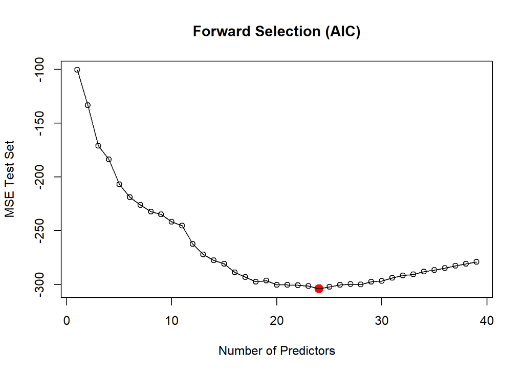

```
## integer(0)
```

```r
plot(x = 1:(ncol(hfi_data_combined_train)-1), y = forward_regression_test_aic,
     main = "Forward Selection (AIC)", ylab = "MSE Test Set",
     xlab = "Number of Predictors") +
  points(x = which.min(forward_regression_test_aic),
         y = forward_regression_test_aic[which.min(forward_regression_test_aic)],
         col="red", pch=19, cex = 1.5) +
  lines(x = 1:(ncol(hfi_data_combined_train)-1), y = forward_regression_test_aic)
```

```r
forward_regression_test_mse[which.min(forward_regression_test_mse)]
```

```
## [1] 0.04212529
```

```r
forward_regression_test_aic[which.min(forward_regression_test_aic)]
```

```
## [1] -304.0694
```

```r
which.min(forward_regression_test_mse)
```

```
## [1] 39
```

```r
which.min(forward_regression_test_aic)
```

```
## [1] 24
```

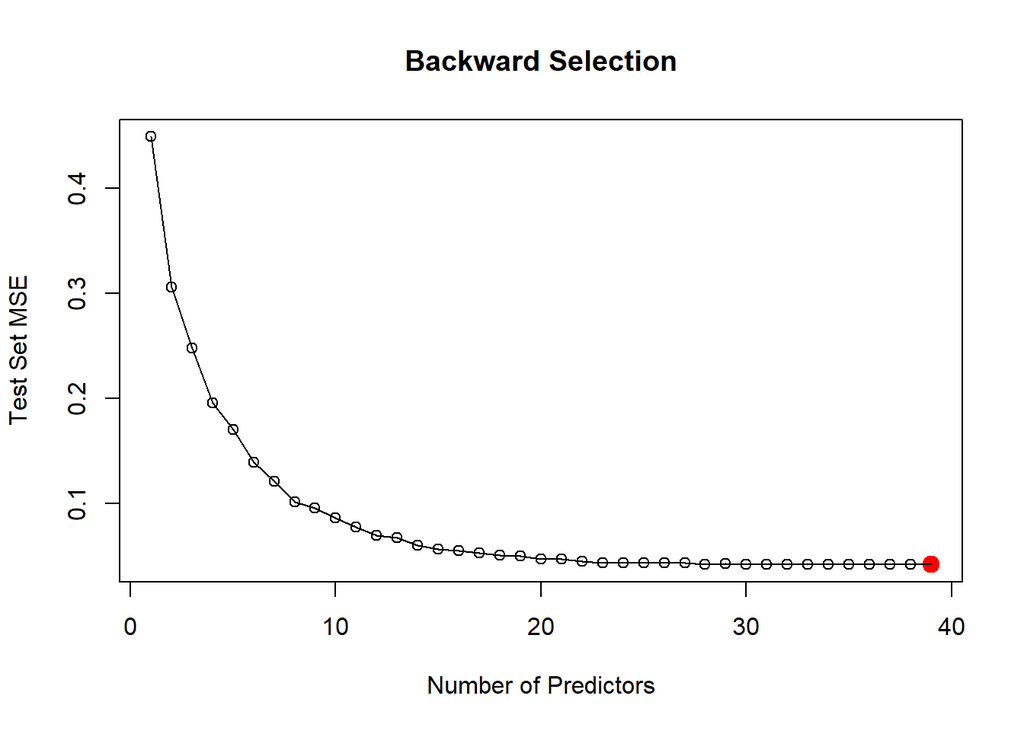

```
## integer(0)
```

```r
# Backward Selection MLR Method
backward_regression = regsubsets(hf_score ~ ., method = "backward",
                                nvmax = (ncol(hfi_data_combined_train)-1),
                                data = hfi_data_combined_train)
# create test model matrix to easily create the predictions
backward_regression_model_matrix = model.matrix(hf_score ~ ., data = hfi_data_combined_test)
# store MSE and AIC results for the test set
backward_regression_test_mse = rep(-1, (ncol(hfi_data_combined_train)-1))
backward_regression_test_aic = rep(-1, (ncol(hfi_data_combined_train)-1))

for( i in 1:(ncol(hfi_data_combined_train)-1)){
  # AGAIN, using pipes to efficiently create predictions
  coef_i = coef(backward_regression, id = i)
  preds = backward_regression_model_matrix[,names(coef_i)] %*% coef_i
  # create the MSE and then AIC
  backward_regression_test_mse[i] = mean((preds - hfi_data_combined_test$hf_score)^2)
  backward_regression_test_aic[i] = 2*length(coef_i) +
    (nrow(hfi_data_combined_test))*log(backward_regression_test_mse[i], base = 10)
}

# Plot the MSE and AIC results with the minimum point highlighted
plot(x = 1:(ncol(hfi_data_combined_train)-1), y = backward_regression_test_mse,
     main = "Backward Selection", ylab = "Test Set MSE",
     xlab = "Number of Predictors") +
  points(x = which.min(backward_regression_test_mse),
         y = backward_regression_test_mse[which.min(backward_regression_test_mse)],
         col="red", pch=19, cex = 1.5) +
  lines(x = 1:(ncol(hfi_data_combined_train)-1), y = backward_regression_test_mse)
```

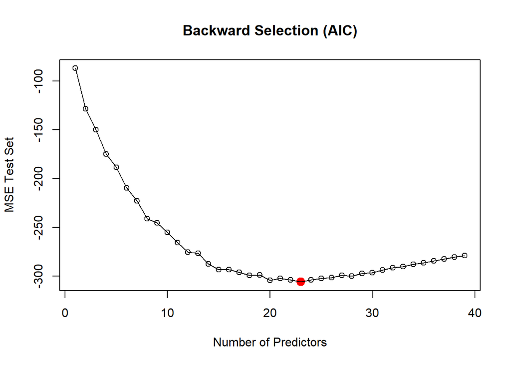

```
## integer(0)
```

```r
plot(x = 1:(ncol(hfi_data_combined_train)-1), y = backward_regression_test_aic,
     main = "Backward Selection (AIC)", ylab = "MSE Test Set",
     xlab = "Number of Predictors") +
  points(x = which.min(backward_regression_test_aic),
         y = backward_regression_test_aic[which.min(backward_regression_test_aic)],
         col="red", pch=19, cex = 1.5) +
  lines(x = 1:(ncol(hfi_data_combined_train)-1), y = backward_regression_test_aic)
```

```r
backward_regression_test_mse[which.min(backward_regression_test_mse)]
```

```
## [1] 0.04212529
```

```r
backward_regression_test_aic[which.min(backward_regression_test_aic)]
```

```
## [1] -306.0917
```

```r
which.min(backward_regression_test_mse)
```

```
## [1] 39
```

```r
which.min(backward_regression_test_aic)
```

```
## [1] 23
```

## 3.3 Cross-Validation and Our Preliminary Findings

## 3.3.1 Implement Cross-Validation on the MLR Models from Above

Cross-Validation utilizes bootstrapping to estimate the MSE in a more robust way to help avoid overfitting a model. We perform cross-validation using the best-subset, forward selection, and backwards deletion models generated above. We get a more robust error (MSE) estimate and take the best from each set of models before testing against the test set as “new” data.

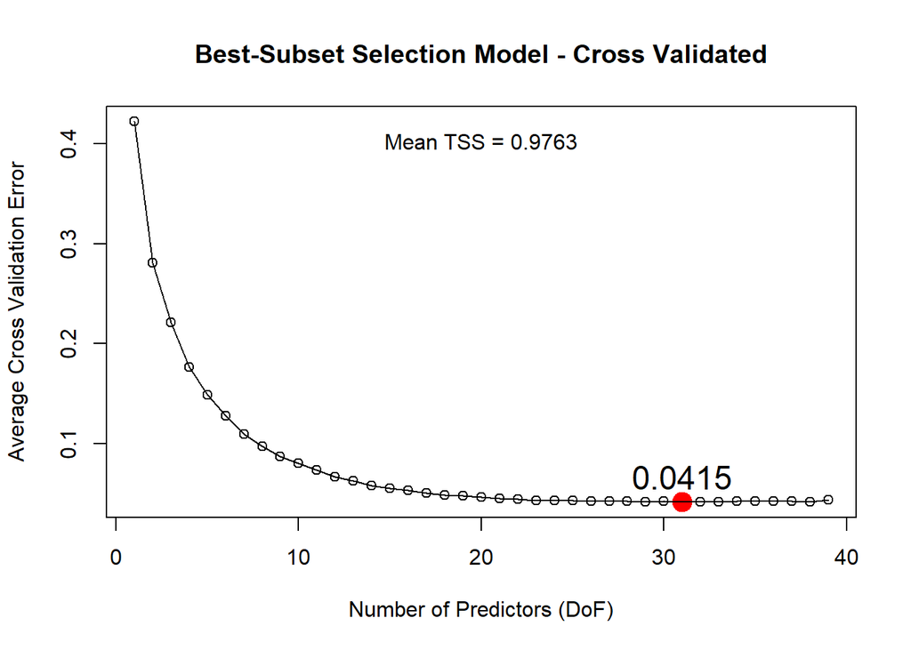

```
## integer(0)
```

```r
set.seed(111)

############################   CROSS-VALIDATION on MLR   ##################
k_folds = 10
par(mfrow=c(1,1))

cv_best_subset_regression_mse = rep(NA, max_predictors_best_subset)
cv_forward_regression_mse = rep(NA, (ncol(hfi_data_combined)-1))
cv_backward_regression_mse = rep(NA, (ncol(hfi_data_combined)-1))

# iterate through all 39 dof for forward, backward and best-subset
for (i in 1:(ncol(hfi_data_combined)-1)){
  # Take the formula for given degree of freedom and set it up for CV
  # Best-Subset Formula; if there is limit on @ predictors, do not calculate
  if( i <= max_predictors_best_subset){
    formula_best_subset_regression = paste( names(coef(best_subset_regression, id = i))[-1],
                                            collapse = " + " )
    formula_best_subset_regression = as.formula( paste("hf_score ~ ", formula_best_subset_regression, sep = ""))
    cv_best_subset_regression = cv.glm(data = hfi_data_combined_train, K = k_folds,
                                       glmfit = glm(formula = formula_best_subset_regression,
                                                    data = hfi_data_combined_train))
    cv_best_subset_regression_mse[i] = cv_best_subset_regression$delta[1]
  }

  # Forward Selection Formula
  formula_forward_regression = paste(names(coef(forward_regression, id = i))[-1],
                                     collapse = " + " )
  formula_forward_regression = as.formula( paste("hf_score ~ ", formula_forward_regression, sep = ""))
  cv_forward_regression = cv.glm(data = hfi_data_combined_train, K = k_folds,
                                 glmfit = glm(formula = formula_forward_regression,
                                              data = hfi_data_combined_train))
  cv_forward_regression_mse[i] = cv_forward_regression$delta[1]

  # Backward Selection Formula
  formula_backward_regression = paste(names(coef(backward_regression, id = i))[-1],
                                     collapse = " + " )
  formula_backward_regression = as.formula( paste("hf_score ~ ", formula_backward_regression, sep = ""))
  cv_backward_regression = cv.glm(data = hfi_data_combined_train, K = k_folds,
                                 glmfit = glm(formula = formula_backward_regression,
                                              data = hfi_data_combined_train))
  cv_backward_regression_mse[i] = cv_backward_regression$delta[1]
}

# 1 by 3 graph plot
par(mfrow=c(1,1))
# Plots of the CV Errors for all 3 Methods
plot(cv_best_subset_regression_mse, main="Best-Subset Selection Model - Cross Validated",
     xlab = "Number of Predictors (DoF)", ylab = "Average Cross Validation Error") +
  points(which.min(cv_best_subset_regression_mse), cv_best_subset_regression_mse[which.min(cv_best_subset_regression_mse)],
       col ="red", cex=2, pch =19) +
  lines(x = 1:(ncol(hfi_data_combined)-1), y = cv_best_subset_regression_mse) +
  text(x=which.min(cv_best_subset_regression_mse), y=min(cv_best_subset_regression_mse),
       labels = paste(round(min(cv_best_subset_regression_mse), 4)), pos=3, cex=1.5) +
  text(x=20, y=max(cv_best_subset_regression_mse),
       labels = paste("Mean TSS =", round(mean_tss_combined, 4)), cex=1, pos=1)
```

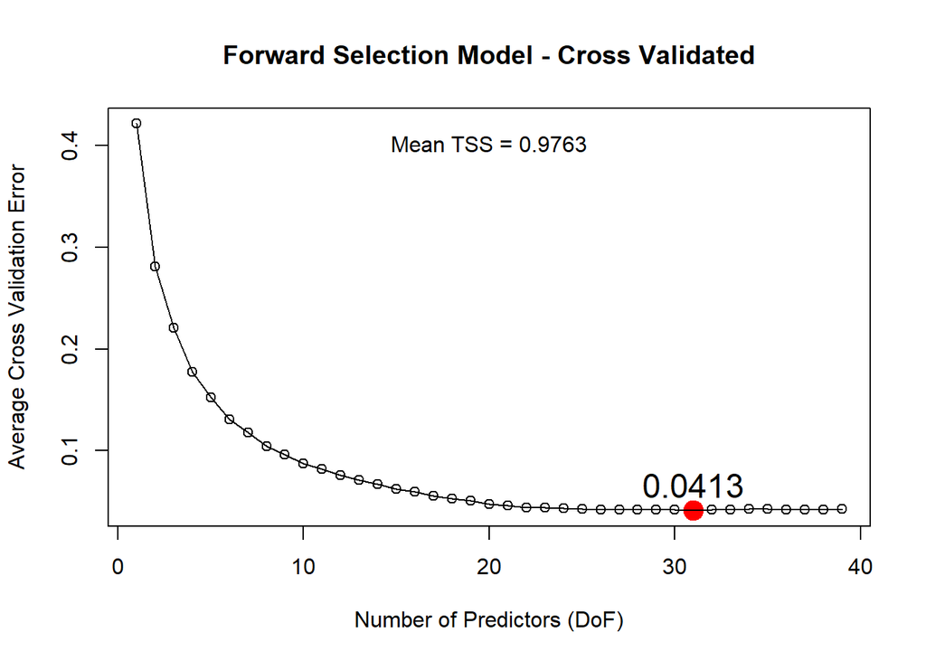

```
## integer(0)
```

```r
plot(cv_forward_regression_mse, main = "Forward Selection Model - Cross Validated",
     xlab = "Number of Predictors (DoF)", ylab = "Average Cross Validation Error") +
  points(which.min(cv_forward_regression_mse), cv_forward_regression_mse[which.min(cv_forward_regression_mse)],
       col ="red", cex=2, pch =19) +
  lines(x = 1:(ncol(hfi_data_combined)-1), y = cv_forward_regression_mse) +
  text(x=which.min(cv_forward_regression_mse), y=min(cv_forward_regression_mse),
       labels = paste(round(min(cv_forward_regression_mse), 4)), pos=3, cex=1.5) +
  text(x=20, y=max(cv_forward_regression_mse),
       labels = paste("Mean TSS =", round(mean_tss_combined, 4)), cex=1, pos=1)
```

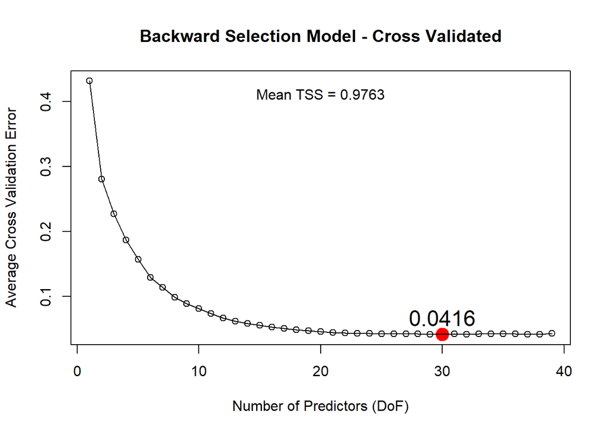

```
## integer(0)
```

```r
plot(cv_backward_regression_mse, main = "Backward Selection Model - Cross Validated",
     xlab = "Number of Predictors (DoF)", ylab = "Average Cross Validation Error") +
  points(which.min(cv_backward_regression_mse), cv_backward_regression_mse[which.min(cv_backward_regression_mse)],
       col ="red", cex=2, pch =19) +
  lines(x = 1:(ncol(hfi_data_combined)-1), y = cv_backward_regression_mse) +
  text(x=which.min(cv_backward_regression_mse), y=min(cv_backward_regression_mse),
       labels = paste(round(min(cv_backward_regression_mse), 4)), pos=3, cex=1.5) +
  text(x=20, y=max(cv_backward_regression_mse),
       labels = paste("Mean TSS =", round(mean_tss_combined, 4)), cex=1, pos=1)
```

```r
paste("Best-Subset MSE: ", cv_best_subset_regression_mse[which.min(cv_best_subset_regression_mse)], "; Number of predictors: ", which.min(cv_best_subset_regression_mse))
```

```
## [1] "Best-Subset MSE:  0.0415338167308513 ; Number of predictors:  31"
```

```r
paste("Forward Selection MSE: ", cv_forward_regression_mse[which.min(cv_forward_regression_mse)], "; Number of predictors: ", which.min(cv_forward_regression_mse))
```

```
## [1] "Forward Selection MSE:  0.0413132950377038 ; Number of predictors:  31"
```

```r
paste("Backward Deletion MSE: ", cv_backward_regression_mse[which.min(cv_backward_regression_mse)], "; Number of predictors: ", which.min(cv_backward_regression_mse))
```

```
## [1] "Backward Deletion MSE:  0.0416274461279086 ; Number of predictors:  30"
```

All 3 models have very low cross-validated MSEs around 0.0415 compared to the Mean TSS of 0.999509. Roughly 95.85 % of variance is explained by all 3 best models. That result is incredibly good. This is odd that the results of multiple linear regression deliver such good results with out adding polynomial terms or interaction terms. This model is already useful enough to stop trying the other methods as MLR delivers high accuracy and very good inferencing for discovering the most significant predictors in terms of affecting the human freedom score.

Now we will test the best model for each method (best-subset, backwards, forwards) against new data (the test set) and see which one performs the best. Whichever model performs the best, we will use it (we will prefer a smaller, simpler model if it does nearly as well).

```r
set.seed(111)

# recreate the best-subset model with the coefs given from Cross-Validation
# USE THE TRAINING DATA
best_subset_best_regression = lm(as.formula(paste('hf_score ~', paste(names(coef(best_subset_regression, id = which.min(
  cv_best_subset_regression_mse )))[2: which.min(cv_best_subset_regression_mse)],
  collapse = ' + '))), data=hfi_data_combined_train )
yhat = predict(best_subset_best_regression, newdata = hfi_data_combined_test)
final_best_subset_mse = mean((yhat - hfi_data_combined_test$hf_score)^2)



# recreate the forward selection model with the coefs given from Cross-Validation
# USE THE TRAINING DATA
best_forward_regression = lm(as.formula(paste('hf_score ~', paste(names(coef(forward_regression, id = which.min(
  cv_forward_regression_mse)))[2: which.min(cv_forward_regression_mse)],
  collapse = ' + '))), data=hfi_data_combined_train )
yhat = predict(best_forward_regression, newdata = hfi_data_combined_test)
final_forward_mse = mean((yhat - hfi_data_combined_test$hf_score)^2)



# recreate the best-subset model with the coefs given from Cross-Validation
# USE THE TRAINING DATA
best_backward_regression = lm(as.formula(paste('hf_score ~', paste(names(coef(backward_regression, id = which.min(
  cv_backward_regression_mse)))[2: which.min(cv_backward_regression_mse)],
  collapse = ' + '))), data=hfi_data_combined_train )
yhat = predict(best_backward_regression, newdata = hfi_data_combined_test)
final_backward_mse = mean((yhat - hfi_data_combined_test$hf_score)^2)


paste("Mean TSS of Test Set:", round(mean_tss_test, 6))
```

```
## [1] "Mean TSS of Test Set: 0.882886"
```

```r
paste("MSE of Best-Subset Model with Test Set:", round(final_best_subset_mse, 6))
```

```
## [1] "MSE of Best-Subset Model with Test Set: 0.042611"
```

```r
paste("MSE of Forward Selection Model with Test Set:", round(final_forward_mse, 6))
```

```
## [1] "MSE of Forward Selection Model with Test Set: 0.042611"
```

```r
paste("MSE of Backward Deletion Model with Test Set:", round(final_backward_mse, 6))
```

```
## [1] "MSE of Backward Deletion Model with Test Set: 0.042272"
```

```r
# I found that the Best-Subset and Forward Selection maybe the same model
# this does depend on the random seed most likely
a = sort(names(coef(forward_regression, id = which.min(cv_forward_regression_mse)))[2: which.min(cv_forward_regression_mse)])
b = sort(names(coef(forward_regression, id = which.min(cv_best_subset_regression_mse)))[2: which.min(cv_best_subset_regression_mse)])
paste("Are Best-Subset and Forward Selection the Same Models? ....", all(a == b))
```

```
## [1] "Are Best-Subset and Forward Selection the Same Models? .... TRUE"
```

We performed cross validation on each model for a given number of predictors with the results found previously for best-subset, backward deletion, and forward selection. The cross-validation helps to add robustness to the estimated MSE, preventing overfitting of the training dataset. It appears that the forward selection and best-subset have the same exact models, hence the identical test MSEs. Ironically, the backward deletion method derives the best model of the three, not best-subset. Granted, the difference is minuscule (like less than 1%). However, we will use the best-subset and forward selection models (as they are the same, assuming the random seed stays the same). This choice is made because the best-subset is exhaustive and the fact that 2 methods returned the same exact linear models gives us more reason to believe this model is better (though both are incredibly accurate and practically identical in R-Squared or correlation).

## 3.3.2 Our Preliminary Analysis So Far

Here are the coefficients of the 3 models (2 are identical).

```r
paste("Backwards Deletion Method Coefficients: ")
```

```
## [1] "Backwards Deletion Method Coefficients: "
```

```r
paste(names(coef(backward_regression, id=which.min(cv_backward_regression_mse))), collapse = ', ' )
```

```
## [1] "(Intercept), pf_ss_homicide, pf_ss_disappearances_disap, pf_ss_disappearances_violent, pf_movement_domestic, pf_movement_foreign, pf_religion_harassment, pf_religion_restrictions, pf_expression_influence, pf_expression_control, pf_identity_sex_male, pf_identity_sex_female, ef_government_cons…
```

```r
paste("")
```

```
## [1] ""
```

```r
paste("Best-Subset and Forward Selection Methods Coefficients (identical): ")
```

```
## [1] "Best-Subset and Forward Selection Methods Coefficients (identical): "
```

```r
paste(names(coef(forward_regression, id = which.min(cv_forward_regression_mse))), collapse = ', ' )
```

```
## [1] "(Intercept), pf_ss_homicide, pf_ss_disappearances_disap, pf_ss_disappearances_violent, pf_movement_domestic, pf_movement_foreign, pf_religion_harassment, pf_religion_restrictions, pf_expression_influence, pf_expression_control, pf_identity_sex_male, pf_identity_sex_female, ef_government_cons…
```

```r
paste("")
```

```
## [1] ""
```

```r
a = sort(names(coef(forward_regression, id = which.min(cv_forward_regression_mse))))
b = sort(names(coef(backward_regression, id=which.min(cv_backward_regression_mse))))

same_predictors = 0
diff_predictors = 0
different_preds = vector()
for (i in 1:length(a)){
  if (a[i] %in% b ){
    same_predictors = same_predictors + 1
  } else{
    diff_predictors = diff_predictors + 1
    different_preds = append(different_preds, a[i])
  }
}

paste("Number of Same Predictors in 2 Models:", same_predictors )
```

```
## [1] "Number of Same Predictors in 2 Models: 31"
```

```r
paste("Number of Different Predictors in 2 Models:", diff_predictors )
```

```
## [1] "Number of Different Predictors in 2 Models: 1"
```

```r
paste("The different predictors are:", different_preds)
```

```
## [1] "The different predictors are: ef_trade_regulatory_compliance"
```

The coefficients in the 3 different models are nearly identical, meaning all 3 models are nearly the same (2 actually are). There is only 1 different predictors between the models, which may be due to the different sizes of the models. The forward selection’s model has 31 predictors within the model, while backwards deletion’s model has 30. Therefore, the near identical models means any of the three can be chosen. We will choose best-subset/forward selection.

Now, we will analyze the significance of the predictors within the model using T-Tests as MLR gives us the ability to easily infer the importance or significance of a predictor.

```r
summary(best_forward_regression)
```

```
##
## Call:
## lm(formula = as.formula(paste("hf_score ~", paste(names(coef(forward_regression,
##     id = which.min(cv_forward_regression_mse)))[2:which.min(cv_forward_regression_mse)],
##     collapse = " + "))), data = hfi_data_combined_train)
##
## Residuals:
##     Min      1Q  Median      3Q     Max
## -0.6707 -0.1308  0.0113  0.1326  0.8244
##
## Coefficients:
##                                  Estimate Std. Error t value Pr(>|t|)
## (Intercept)                      0.331258   0.122962   2.694 0.007177 **
## pf_ss_homicide                   0.054883   0.002787  19.690  < 2e-16 ***
## pf_ss_disappearances_disap       0.007723   0.002589   2.983 0.002923 **
## pf_ss_disappearances_violent     0.014433   0.004464   3.233 0.001264 **
## pf_movement_domestic             0.018801   0.002422   7.761 2.05e-14 ***
## pf_movement_foreign              0.016882   0.002260   7.468 1.75e-13 ***
## pf_religion_harassment           0.024979   0.009287   2.690 0.007269 **
## pf_religion_restrictions         0.023538   0.005089   4.625 4.23e-06 ***
## pf_expression_influence          0.043360   0.007257   5.975 3.19e-09 ***
## pf_expression_control            0.049226   0.008606   5.720 1.40e-08 ***
## pf_identity_sex_male             0.021200   0.002327   9.110  < 2e-16 ***
## pf_identity_sex_female           0.016234   0.002574   6.307 4.25e-10 ***
## ef_government_consumption        0.039983   0.003854  10.375  < 2e-16 ***
## ef_legal_courts                  0.075238   0.005579  13.486  < 2e-16 ***
## ef_legal_military                0.046731   0.004002  11.677  < 2e-16 ***
## ef_legal_enforcement             0.052020   0.005071  10.259  < 2e-16 ***
## ef_legal_gender                  1.034573   0.066013  15.672  < 2e-16 ***
## ef_money_growth                  0.033803   0.007150   4.728 2.59e-06 ***
## ef_money_sd                      0.035833   0.005329   6.724 2.95e-11 ***
## ef_money_inflation               0.030944   0.006656   4.649 3.77e-06 ***
## ef_money_currency                0.026736   0.002373  11.268  < 2e-16 ***
## ef_trade_tariffs_mean            0.057275   0.009305   6.155 1.08e-09 ***
## ef_trade_regulatory_compliance   0.011359   0.008203   1.385 0.166453
## ef_trade_regulatory              0.044053   0.013172   3.344 0.000855 ***
## ef_trade_black                   0.010797   0.006479   1.667 0.095919 .
## ef_trade_movement_capital        0.015497   0.003179   4.874 1.27e-06 ***
## ef_trade_movement_visit          0.018729   0.002293   8.168 9.30e-16 ***
## ef_regulation_credit_private     0.006343   0.004115   1.542 0.123486
## ef_regulation_credit             0.037836   0.007988   4.737 2.48e-06 ***
## ef_regulation_labor_hours        0.013880   0.003554   3.905 0.000100 ***
## ef_regulation_labor_conscription 0.005521   0.001745   3.164 0.001604 **
## ---
## Signif. codes:  0 '***' 0.001 '**' 0.01 '*' 0.05 '.' 0.1 ' ' 1
##
## Residual standard error: 0.2009 on 1013 degrees of freedom
## Multiple R-squared:  0.9608, Adjusted R-squared:  0.9597
## F-statistic:   828 on 30 and 1013 DF,  p-value: < 2.2e-16
```

The predictors that seem most significant (3 asterisks) are:

- pf_ss_homicide: a number based on the number of homicides within the country. More homicides means less human freedom as life is being taken away unqillingly.
- pf_movement_domestic: The freedom of citizens to move around the country at their will. Countries that prevent citizens from easily moving from city to city will tend to have less human freedom.
- pf_movement_foreign: the same as the above, but for foreigners’ movement within the country.
- pf_religion_restrictions: the freedom to practice one’s religion. The more lenient countries are with religion, the greater the human freedom tends to be.
- pf_expression_influence, pf_expression_control: the degree that one’s expression (like content of meetings or protests and influence over media) is controlled by the country. Country that allows basically any form of expression will tend to have higher human freedom overall.
- pf_identity_sex_male, pf_identity_sex_female: the freedom to identify and have equal legal protections based on sex. The more equal a country treats men and women, the human freedom tends to be greater.
- ef_government_consumption: the amount of money the government spends. The more the government spends, the more free the countries are. This runs counter to the libertarian ideal that CATO follows.
- ef_legal_courts, ef_legal_military, ef_legal_enforcement, ef_legal_gender: the equality within the judicial system for courts (the amount, availability, and impartiality), the fairness towards the military legal issues, the fairness that laws are enforced, and equality of laws between genders. The more fair and equal and just the judicial system is, the greater the human freedom tends to be.
- ef_money_growth, ef_money_sd, ef_money_inflation, ef_money_currency: The degree the monetary system follows libertarian ideals. AKA, no manipulation of currency or of the money supply for artificial money generation. These variables are quite murky, so beware. I am not sure how they calculate this and how accurate their data is. Additionally, the USA has artificially created *a lot* of money and therefore they should have poor scores, but the USA does not. However, China does as they publicly (kinda) manipulate currency. Basically, I would take these predictors with a ground of salt. The less the government messes with the money supply, interest rates, and monetary policy, the greater the human freedom tends to be.
- ef_trade_tariffs_mean, ef_trade_regulatory: the mean of the trade tariffs and regulation on trade (often affecting trade out-of-country). The greater the tariffs, the less economic freedom according to libertarian views. If the tariffs are small, the human freedom tends to be greater.
- ef_trade_movement_capital, ef_trade_movement_visit: how easily capital can be moved around the country for citizens and visitors (foreigners). The easier money/capital can be moved, then the human freedom tends to be greater.
- ef_regulation_credit, ef_regulation_labor_hours: how well regulated the credit sector is and how much time is spent on enforcing regulation. The CATO institute believes that the credit industry needs to have some oversight to prevent bad actors from taking advantage from no regulation. However, they also will there was very little time spend on enforcing regulation. Therefore, this combo of predictors is again wierd. It is hard to draw many conclusions from it.

```r
set.seed(111)
simple_mlr_model = lm(hf_score ~ pf_ss_homicide + pf_movement_domestic + pf_movement_foreign + pf_religion_restrictions + pf_expression_influence +
                        pf_expression_control + ef_legal_courts + ef_legal_military + ef_legal_enforcement + ef_legal_gender + ef_money_inflation +
                        ef_trade_regulatory + ef_trade_movement_visit, data = hfi_data_combined_train)
yhat = predict(simple_mlr_model, newdata = hfi_data_combined_test)
simple_mlr_test_mse = mean((yhat - hfi_data_combined_test$hf_score)^2)

paste("The Mean TSS of the Test Set:", round(mean_tss_test, 6))
```

```
## [1] "The Mean TSS of the Test Set: 0.882886"
```

```r
paste("The Test MSE of the Simple MLR Model:", round(simple_mlr_test_mse, 6))
```

```
## [1] "The Test MSE of the Simple MLR Model: 0.114887"
```

```r
paste("The R-Squared of the Simple MLR Model:", round(1 - simple_mlr_test_mse / mean_tss_test, 6))
```

```
## [1] "The R-Squared of the Simple MLR Model: 0.869874"
```

The resulting Test MSE is 0.114887 which is worse than the 30+ predictor models above, but still explains roughly 86.99% of the variance within the dataset. The results are preliminary, but they do seem to indicate the human freedom index could be estimated with substantially fewer predictors than the 39 in the entire dataset. We wil return to this at the end of the analysis.

## 3.4 Dimension Reduction Methods:

We performed additional methods to try and reduce the number of predictors within the linear models. The techniques utilized were Ridge, Lasso, principle component analysis (PCA), and partial least squares (PLS). Due to the high accuracy of the previous models, we will only briefly analyze these findings. We strongly believe the model should not become overly complex as we will lose some inferencing ability with some of the following techniques (PCA, PLS).

### 3.4.1 Ridge

```r
# simply used to get same results regardless of run. Methods should be robust to the seed changing, though
set.seed(111)

#  RIDGE REGRESSION METHOD
# grid holds the range of LAMBDA values we use

grid = 10^seq(10,-2, length = 1000)
regression_model_train = model.matrix(hf_score ~ ., data = hfi_data_combined_train)[,-1]
regression_model_test = model.matrix(hf_score ~ ., data = hfi_data_combined_test)[,-1]

# Perform Cross-Validation and test on the test set to get MSE's
# Get the best lambda from CV
cv_ridge_regression = cv.glmnet(regression_model_train, hfi_data_combined_train$hf_score,
                                alpha = 0, lambda = grid, thresh = 1e-12)
# Get the single, best model with CV best lambda
best_ridge_model = glmnet(regression_model_train, hfi_data_combined_train$hf_score,
                          alpha = 0, lambda = cv_ridge_regression$lambda.min, thresh = 1e-12)
# Store the best Lambda, and get MSE by predicting with test set
best_lambda_ridge <- cv_ridge_regression$lambda.min
ridge_model_predictions = predict(best_ridge_model,
                                  newx = regression_model_test,
                                  s = cv_ridge_regression$lambda.min)
best_ridge_model_mse = mean((hfi_data_combined_test$hf_score - ridge_model_predictions)^2)

best_lambda_ridge
```

```
## [1] 0.03669142
```

```r
best_ridge_model$beta
```

```
## 39 x 1 sparse Matrix of class "dgCMatrix"
##                                             s0
## pf_ss_homicide                     0.048143239
## pf_ss_disappearances_disap         0.009107639
## pf_ss_disappearances_violent       0.010751955
## pf_ss_disappearances_fatalities    0.012108566
## pf_ss_disappearances_injuries     -0.008094916
## pf_movement_domestic               0.018365280
## pf_movement_foreign                0.016600531
## pf_religion_harassment             0.022107300
## pf_religion_restrictions           0.026782092
## pf_expression_killed               0.004940367
## pf_expression_jailed               0.005380067
## pf_expression_influence            0.040909831
## pf_expression_control              0.050735317
## pf_identity_sex_male               0.020631078
## pf_identity_sex_female             0.017276297
## ef_government_consumption          0.034299065
## ef_legal_courts                    0.067955677
## ef_legal_military                  0.040888903
## ef_legal_enforcement               0.049533817
## ef_legal_gender                    0.980300442
## ef_money_growth                    0.029226572
## ef_money_sd                        0.039288578
## ef_money_inflation                 0.027941977
## ef_money_currency                  0.023809489
## ef_trade_tariffs_mean              0.047530346
## ef_trade_tariffs_sd               -0.007878708
## ef_trade_tariffs                   0.023060196
## ef_trade_regulatory_compliance     0.014764128
## ef_trade_regulatory                0.037602317
## ef_trade_black                     0.012040169
## ef_trade_movement_capital          0.017686057
## ef_trade_movement_visit            0.016960368
## ef_regulation_credit_private       0.008702898
## ef_regulation_credit               0.033870605
## ef_regulation_labor_minwage        0.004212930
## ef_regulation_labor_hours          0.013373527
## ef_regulation_labor_conscription   0.005972801
## ef_regulation_business_start       0.024265085
## ef_regulation_business_compliance  0.004767761
```

```r
mean_tss_test
```

```
## [1] 0.882886
```

```r
best_ridge_model_mse
```

```
## [1] 0.04268541
```

Using the 10-fold cross validated best lamdba of about 0.036691, in the Ridge model all 39 variables remain in the model.The test MSE rises to 0.042685. The result delivers a model with no predictor removed no improvement to the test MSE of the MLR (the test MSE was 0.042611). The Ridge model fails to simplify the existing model.

### 3.4.2 Lasso

```r
set.seed(111)

# LASSO REGRESSION
# perform same thing as RIDGE but with alpha==1; get MSE's
cv_lasso_regression = cv.glmnet(regression_model_train, hfi_data_combined_train$hf_score,
                                alpha = 1, lambda = grid, thresh = 1e-12)
best_lasso_regression = glmnet(regression_model_train, hfi_data_combined_train$hf_score,
                               alpha = 1, lambda = cv_lasso_regression$lambda.min, thresh = 1e-12)
best_lambda_lasso <- cv_lasso_regression$lambda.min
lasso_model_predictions = predict(best_lasso_regression,
                                  newx = regression_model_test,
                                  s = cv_lasso_regression$lambda.min)
best_lasso_model_mse = mean((hfi_data_combined_test$hf_score - lasso_model_predictions)^2)

# this code counts number of parameters that were set to 0
# This is the difference between RIDGE and LASSO
#     RIDGE: lowers the Betas to reduce degree of Beta terms
#     LASSO: lowers the Betas to 0 to remove completely from model
sum_betas_0s = 0
for( i in 1:length(best_lasso_regression$beta[,1])){
  if(best_lasso_regression$beta[i,1]==0 ){
    sum_betas_0s = sum_betas_0s + 1
  }
}

sum_betas_0s
```

```
## [1] 4
```

```r
best_lambda_lasso
```

```
## [1] 0.01
```

```r
mean_tss_test
```

```
## [1] 0.882886
```

```r
best_lasso_model_mse
```

```
## [1] 0.04306138
```

Using the 10-fold cross validated best lambda of 0.01, the resulting Lasso is a better model than Ridge because it removes several predictors. This Lasso model removes 4 predictors, which is somewhat underwhelming considering we have 39 predictors. The test MSE of 0.043061 is slightly worse than Ridge (0.042685). Therefore, both the Ridge and Lasso models do not help us significantly as both models are still more complex than the forward selection model, backward deletion model, and best-subset model, yet fail to deliver better results.

### 3.4.3 PCR: Principle Component Reduction

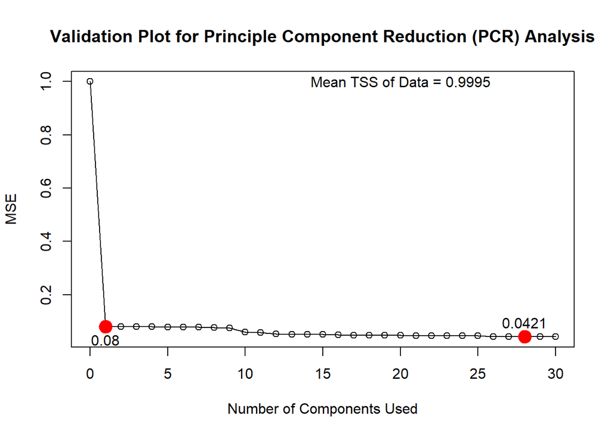

```
## integer(0)
```

```r
set.seed(111)

### DIMENSION REDUCTION METHODS ###
# Principle Component Reduction (PCR)
pcr_model = pcr(as.formula(paste("hf_score ~", paste(names(coef(forward_regression, id = which.min(cv_forward_regression_mse)))[2:which.min(cv_forward_regression_mse)],
                                 collapse = " + "))), data = hfi_data_combined_train, scale = TRUE, validation = "CV")
plot(x=0:pcr_model$ncomp,
     y=c(pcr_model$validation$PRESS0, pcr_model$validation$PRESS )/pcr_model$validation$PRESS0,
     main = "Validation Plot for Principle Component Reduction (PCR) Analysis",
     ylab = "MSE", xlab = "Number of Components Used") +
  lines(x=0:pcr_model$ncomp,
       y=c(pcr_model$validation$PRESS0, pcr_model$validation$PRESS )/pcr_model$validation$PRESS0) +
  points(x = which.min(pcr_model$validation$PRESS),
         y = min(pcr_model$validation$PRESS)/pcr_model$validation$PRESS0,
         col ="red", cex=2, pch =19) +
  text(x = which.min(pcr_model$validation$PRESS),
       y = min(pcr_model$validation$PRESS)/pcr_model$validation$PRESS0,
       labels=round(min(pcr_model$validation$PRESS)/pcr_model$validation$PRESS0, 4), pos = 3) +
  points(x = 1, y = pcr_model$validation$PRESS[1]/pcr_model$validation$PRESS0,
         col ="red", cex=2, pch =19) +
  text(x = 1, y = pcr_model$validation$PRESS[1]/pcr_model$validation$PRESS0,
       labels = round(pcr_model$validation$PRESS[1]/pcr_model$validation$PRESS0, 4), pos = 1) +
  text(x=20, y=1, labels = paste("Mean TSS of Data =", round(mean_tss_train,4)))
```

```r
yhat = predict(pcr_model, newdata = hfi_data_combined_test, ncomp = which.min(pcr_model$validation$PRESS))
best_pcr_model_test_mse = mean((yhat - hfi_data_combined_test$hf_score)^2)

yhat = predict(pcr_model, newdata = hfi_data_combined_test, ncomp = 1)
pcr_model_1_comp_test_mse = mean((yhat - hfi_data_combined_test$hf_score)^2)

yhat = predict(pcr_model, newdata = hfi_data_combined_test, ncomp = 9)
pcr_model_9_comp_test_mse = mean((yhat - hfi_data_combined_test$hf_score)^2)

yhat = predict(pcr_model, newdata = hfi_data_combined_test, ncomp = 10)
pcr_model_10_comp_test_mse = mean((yhat - hfi_data_combined_test$hf_score)^2)



paste("The Mean TSS for the Test Set:", round(mean_tss_test, 6))
```

```
## [1] "The Mean TSS for the Test Set: 0.882886"
```

```r
paste("The Test MSE for the Forward Selection Model:", round(final_forward_mse, 6))
```

```
## [1] "The Test MSE for the Forward Selection Model: 0.042611"
```

```r
paste("The Test MSE for the Best PCR Model with",which.min(pcr_model$validation$PRESS), "Components:", round(best_pcr_model_test_mse, 6))
```

```
## [1] "The Test MSE for the Best PCR Model with 28 Components: 0.042747"
```

```r
paste("The Test MSE for the Best PCR Model with 1 Component:", round(pcr_model_1_comp_test_mse, 6))
```

```
## [1] "The Test MSE for the Best PCR Model with 1 Component: 0.087674"
```

```r
paste("The Test MSE for the Best PCR Model with 11 Components:", round(pcr_model_9_comp_test_mse, 6))
```

[output not shown]

```r
paste("The Test MSE for the Best PCR Model with 10 Components:", round(pcr_model_10_comp_test_mse, 6))
```

```
## [1] "The Test MSE for the Best PCR Model with 10 Components: 0.063762"
```

Using 10-fold cross validation, the lowest average root MSE is the one corresponding to M=28 components. The resulting PCR gives a test MSE of 0.042747, and is slightly worse than the linear models shown earlier. Notably, the validation plot shows that after the first component is added, only marginal benefits are gained from adding more components. After running the PCR with 1 component results in a test MSE of 0.087674. The test MSE is still very accurate, but not improved compared to the forward selection MLR test MSE of 0.042611.

A large issue with PCR, is the predictors are transformed into a combination of each other to reduce the dimensionality. However, this does not mean the model is simpler. It just means there is 1 predictor for a pair of predictors. Additionally, the transformation of the predictors distort our understanding of the significance and importance of specific predictors on human freedom. Therefore, we prefer the forward selection and best-subset models from the MLR section above. More accuracy and more inferencing. Literally, the MLR is strictly better.

### 3.4.4 PLS

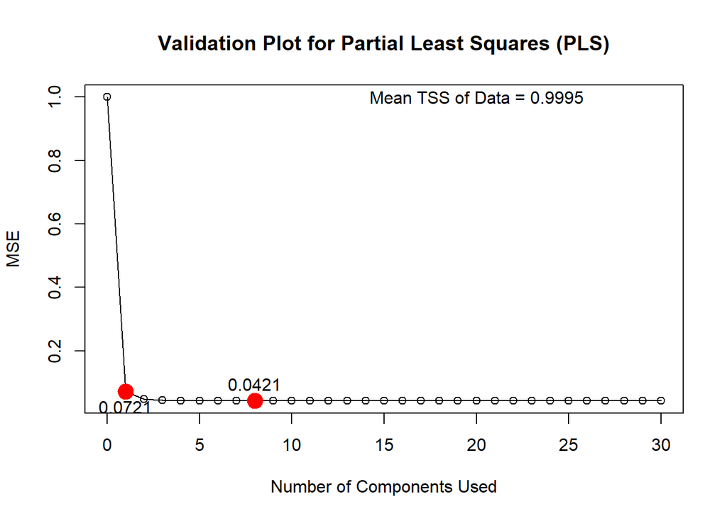

```
## integer(0)
```

```r
set.seed(111)

# Partial Least Squares (PLS) Model
pls_model = plsr(as.formula(paste("hf_score ~", paste(names(coef(forward_regression, id = which.min(cv_forward_regression_mse)))[2:which.min(cv_forward_regression_mse)],
                                 collapse = " + "))),  data = hfi_data_combined_train, scale = TRUE,
                validation = "CV")
plot(x=0:pls_model$ncomp,
     y=c(pls_model$validation$PRESS0, pls_model$validation$PRESS )/pls_model$validation$PRESS0,
     main = "Validation Plot for Partial Least Squares (PLS)",
     ylab = "MSE", xlab = "Number of Components Used") +
  lines(x=0:pls_model$ncomp,
        y=c(pls_model$validation$PRESS0, pls_model$validation$PRESS )/pls_model$validation$PRESS0) +
  points(x = which.min(pls_model$validation$PRESS),
         y = min(pls_model$validation$PRESS)/pls_model$validation$PRESS0,
         col ="red", cex=2, pch =19) +
  text(x = which.min(pls_model$validation$PRESS),
       y = min(pls_model$validation$PRESS)/pls_model$validation$PRESS0,
       labels=round(min(pls_model$validation$PRESS)/pls_model$validation$PRESS0, 4), pos = 3) +
  points(x = 1, y = pls_model$validation$PRESS[1]/pls_model$validation$PRESS0,
         col ="red", cex=2, pch =19) +
  text(x = 1, y = pls_model$validation$PRESS[1]/pls_model$validation$PRESS0,
       labels = round(pls_model$validation$PRESS[1]/pls_model$validation$PRESS0, 4), pos = 1) +
  text(x=20, y=1, labels = paste("Mean TSS of Data =", round(mean_tss_train,4)))
```

```r
yhat = predict(pls_model, newdata = hfi_data_combined_test, ncomp = which.min(pls_model$validation$PRESS))
best_pls_model_test_mse = mean((yhat - hfi_data_combined_test$hf_score)^2)

yhat = predict(pls_model, newdata = hfi_data_combined_test, ncomp = 1)
pls_model_1_comp_test_mse = mean((yhat - hfi_data_combined_test$hf_score)^2)

yhat = predict(pls_model, newdata = hfi_data_combined_test, ncomp = 2)
pls_model_2_comp_test_mse = mean((yhat - hfi_data_combined_test$hf_score)^2)

paste("The Mean TSS for the Test Set:", round(mean_tss_test, 6))
```

```
## [1] "The Mean TSS for the Test Set: 0.882886"
```

```r
paste("The Test MSE for the Forward Selection Model:", round(final_forward_mse, 6))
```

```
## [1] "The Test MSE for the Forward Selection Model: 0.042611"
```

```r
paste("The Test MSE for the Best PLS Model with",which.min(pls_model$validation$PRESS), "Components:", round(best_pls_model_test_mse, 6))
```

```
## [1] "The Test MSE for the Best PLS Model with 8 Components: 0.042749"
```

```r
paste("The Test MSE for the Best PLS Model with 1 Component:", round(pls_model_1_comp_test_mse, 6))
```

```
## [1] "The Test MSE for the Best PLS Model with 1 Component: 0.078617"
```

```r
paste("The Test MSE for the Best PLS Model with 2 Components:", round(pls_model_2_comp_test_mse, 6))
```

```
## [1] "The Test MSE for the Best PLS Model with 2 Components: 0.048627"
```

### 3.4.5 Dimension Reduction Findings

These methods failed to simplify the model in a meaningful way. Again, it is important to highlight that the accuracy of the MLR models from forward, backward, best-subset, and cross-validated were all highly accurate. These models explained over 90% (and often 95%) of variance, therefore the reduction is not really necessary as the model benefits from having all the variables included. If the MLR was not as effective as a predictor and inferencing tool, we would look into a more stringent analysis using these dimension reduction techniques.

While some methods deliver results on par with linear models, the linear models are superior for inferencing. We are very interested in the inferencing capabilities of the linear models to draw conclusions about which predictors are the most significant and affect human freedom score the most.

### We create a smaller MLR model at the **end** of the project using hand-picked predictors based on all the methods for inferencing.

We have already done this partially already, but there maybe changes to the variables chosen by the end of the analysis.

# 4. Non-Linear Methods

We have focused on linear methods of analyzing trends in data. Now we will pivot to some non-linear methods like polynomial regression, splines, Generalized Additive Models (GAMs), and K-Nearest Neighbors (KNN).

## 4.1 Polynomial Regression

This regression using polynomial terms is not necessary. We do not really expect polynomial trends within the data and these polynomial curves tend to add variance and less interpretability to the end results. However, we still try the polynomial curves to see if they do offer insights to the data.

Initially, we need to analyze the pair-plots that showcase the correlation between variables. The focus is hf_score with the most significant variables found from the best-subset regression of size 10 predictors. This model was chosen as these will probably be the most significant variables we know so far. This isolates which predictors we should analyze for non-linear trends to the primary ones.

The Pair-Plots:

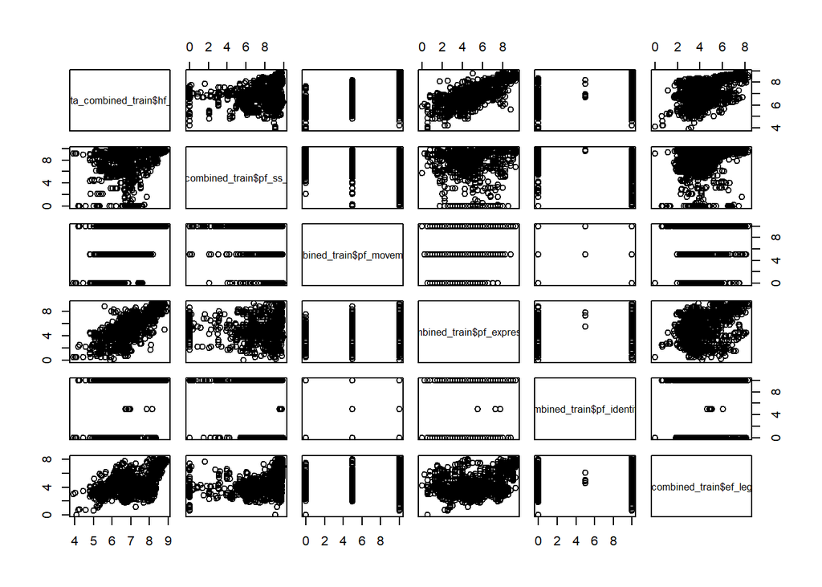

```r
pairs(hfi_data_combined_train$hf_score ~ hfi_data_combined_train$pf_ss_homicide + hfi_data_combined_train$pf_movement_domestic +
        hfi_data_combined_train$pf_expression_control + hfi_data_combined_train$pf_identity_sex_male + hfi_data_combined_train$ef_legal_courts)
```

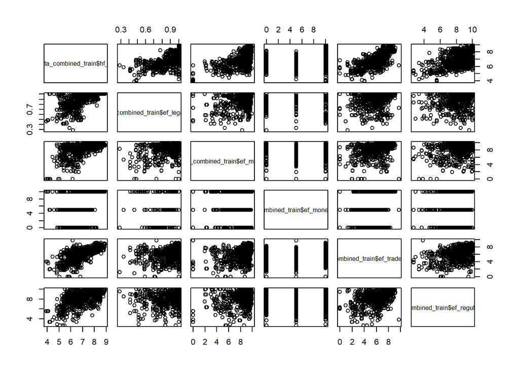

```r
pairs(hfi_data_combined_train$hf_score ~ hfi_data_combined_train$ef_legal_gender + hfi_data_combined_train$ef_money_sd +
        hfi_data_combined_train$ef_money_currency + hfi_data_combined_train$ef_trade_regulatory + hfi_data_combined_train$ef_regulation_credit)
```

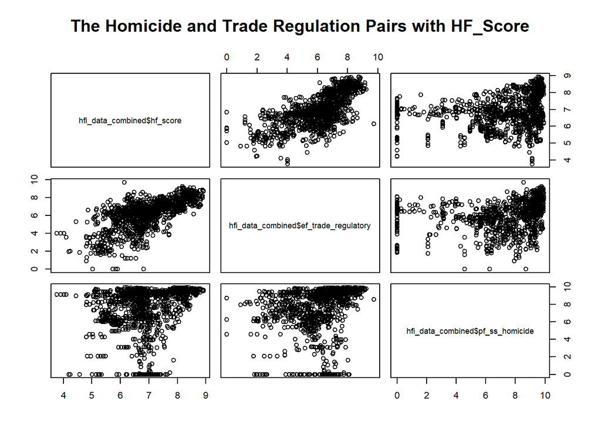

```r
pairs(hfi_data_combined$hf_score ~ hfi_data_combined$ef_trade_regulatory + hfi_data_combined$pf_ss_homicide,
      main="The Homicide and Trade Regulation Pairs with HF_Score")
```

Overall, the pair plots do not indicate a large amount of polynomial trends, but more that certain values are more common (often skewed or multi-modal). We isolated that the clearest non-linear relationships with hf_score: pf_ss_homicide and ef_trade_regulatory.

Let’s first test this with polynomial regression:

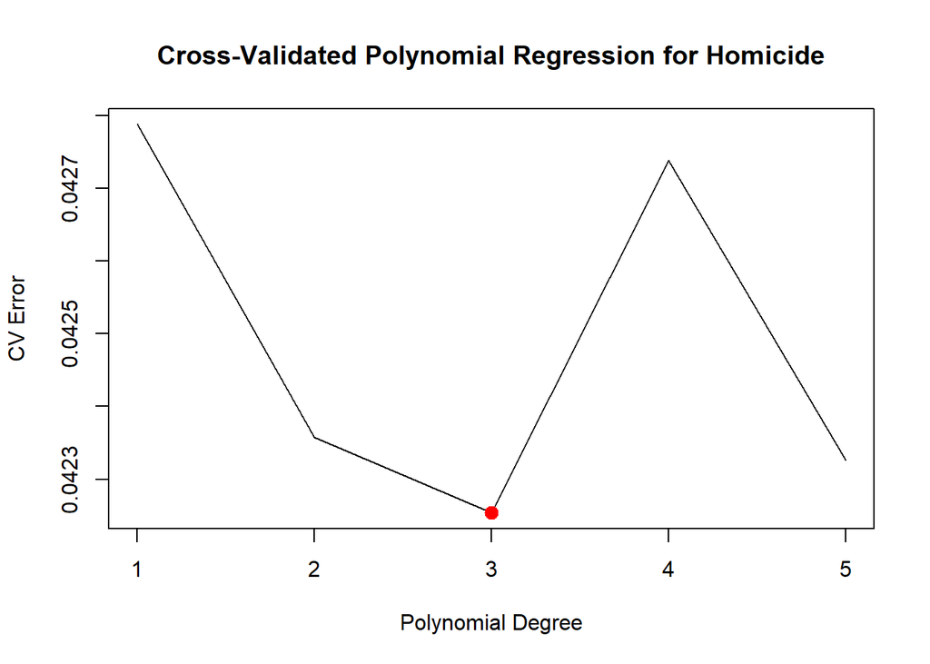

```r
set.seed(111)
max_poly_term = 5
par(mfrow=c(1,1))

CVerror_homocide = rep(0, max_poly_term)
for (i in 1:max_poly_term) {
    fit = glm(hf_score ~ poly(pf_ss_homicide, i) + . - pf_ss_homicide, data = hfi_data_combined_train)
    CVerror_homocide[i] = cv.glm(hfi_data_combined_train, fit, K = 10)$delta[1]
}
plot(CVerror_homocide, main = "Cross-Validated Polynomial Regression for Homicide",
     xlab = "Polynomial Degree", ylab = "CV Error", type = "l")
points(which.min(CVerror_homocide), CVerror_homocide[which.min(CVerror_homocide)], col = "red",cex=2,pch =20)
```

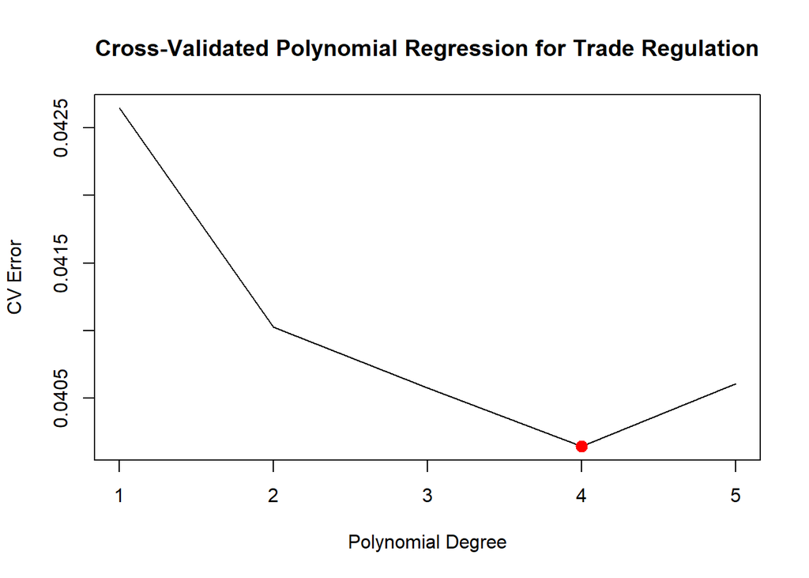

```r
CVerror_trade_reg = rep(0, max_poly_term)
for (i in 1:max_poly_term) {
    fit = glm(hf_score~ poly(ef_trade_regulatory, i) + . - ef_trade_regulatory, data = hfi_data_combined_train)
    CVerror_trade_reg[i] = cv.glm(hfi_data_combined_train, fit, K = 10)$delta[1]
}
plot(CVerror_trade_reg, main = "Cross-Validated Polynomial Regression for Trade Regulation",
     xlab = "Polynomial Degree", ylab = "CV Error", type = "l")
points(which.min(CVerror_trade_reg), CVerror_trade_reg[which.min(CVerror_trade_reg)], col = "red",cex=2,pch =20)
```

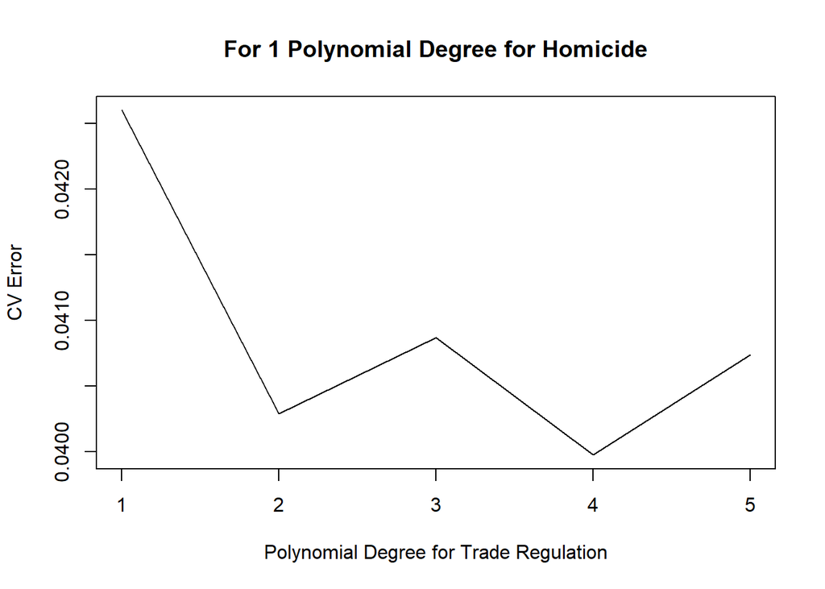

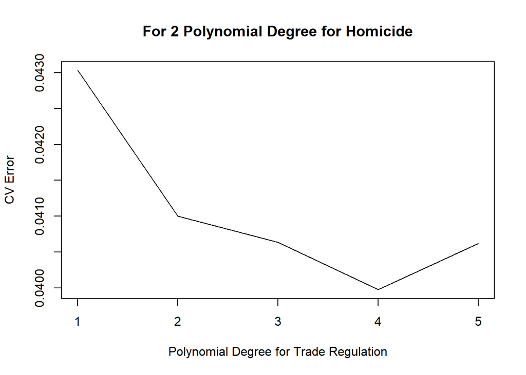

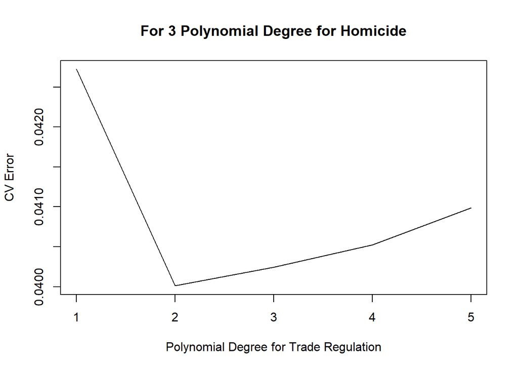

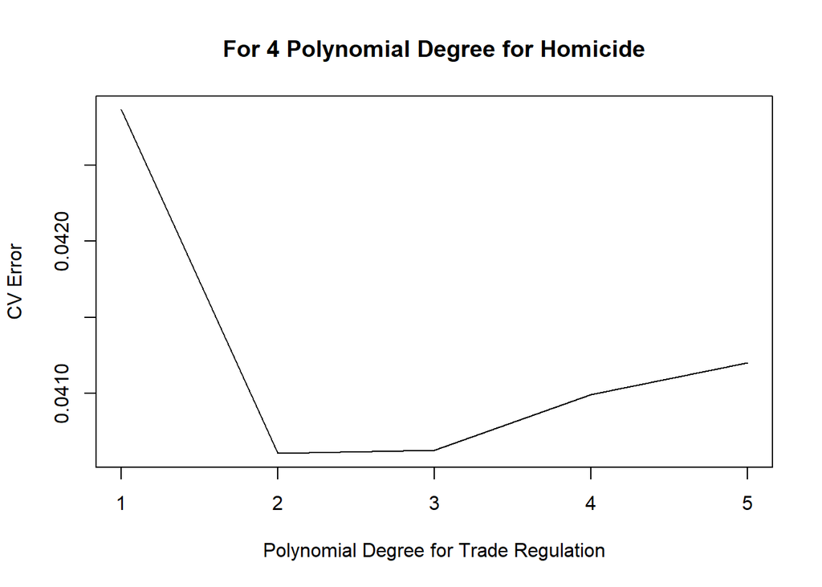

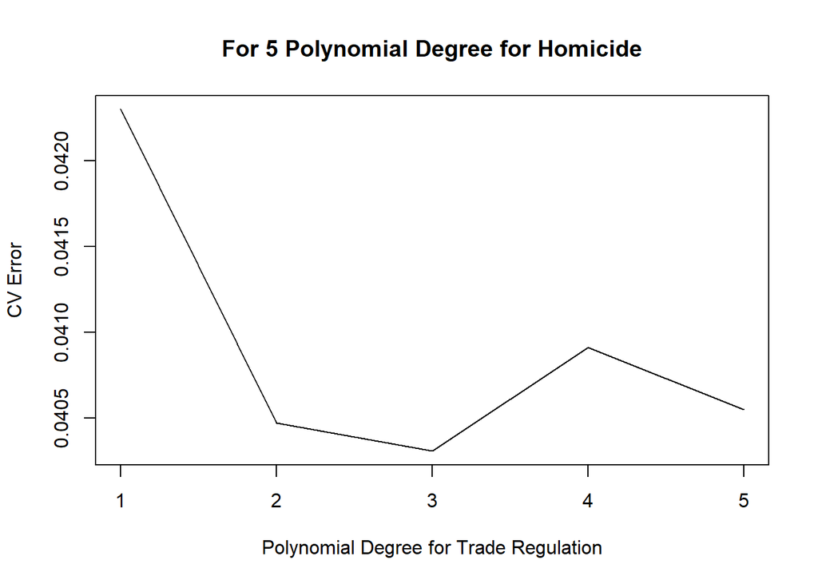

```r
CVerror_combined = matrix(data=rep(rep(0, max_poly_term), max_poly_term), nrow=max_poly_term, ncol = max_poly_term)
for (i in 1:max_poly_term) {
  for (j in 1:max_poly_term){
    fit = glm(hf_score~ poly(pf_ss_homicide, i) + poly(ef_trade_regulatory, j) + . -
                ef_trade_regulatory - pf_ss_homicide, data = hfi_data_combined_train)
    CVerror_combined[i, j] = cv.glm(hfi_data_combined_train, fit, K = 10)$delta[1]
  }
  plot(CVerror_combined[i,1:max_poly_term],
       main = paste("For", i, "Polynomial Degree for Homicide"),
       xlab = "Polynomial Degree for Trade Regulation", ylab = "CV Error", type = "l")
}
```

```r
polyfit_homicide = lm(hf_score ~ poly(pf_ss_homicide, which.min(CVerror_homocide)) + . -
                        pf_ss_homicide, data = hfi_data_combined_train)
polyfit_trade_reg = lm(hf_score ~ poly(ef_trade_regulatory, which.min(CVerror_trade_reg)) + . -
                         ef_trade_regulatory, data = hfi_data_combined_train)

polyfit_combined = lm(hf_score ~ poly(ef_trade_regulatory,
                                      arrayInd(which.min(CVerror_combined),
                                               dim(CVerror_combined))[1,2]) +
                        poly(pf_ss_homicide, arrayInd(which.min(CVerror_combined),
                                                      dim(CVerror_combined))[1,1]) +
                        . - ef_trade_regulatory - pf_ss_homicide, data = hfi_data_combined_train)

summary(polyfit_homicide)
```

```
##
## Call:
## lm(formula = hf_score ~ poly(pf_ss_homicide, which.min(CVerror_homocide)) +
##     . - pf_ss_homicide, data = hfi_data_combined_train)
##
## Residuals:
##      Min       1Q   Median       3Q      Max
## -0.64870 -0.12449  0.01113  0.12901  0.83843
##
## Coefficients:
##                                                     Estimate Std. Error t value
## (Intercept)                                         0.547950   0.140994   3.886
## poly(pf_ss_homicide, which.min(CVerror_homocide))1  4.790312   0.279480  17.140
## poly(pf_ss_homicide, which.min(CVerror_homocide))2  0.463717   0.256543   1.808
## poly(pf_ss_homicide, which.min(CVerror_homocide))3 -0.236718   0.223218  -1.060
## pf_ss_disappearances_disap                          0.007781   0.002656   2.929
## pf_ss_disappearances_violent                        0.011086   0.005830   1.902
## pf_ss_disappearances_fatalities                     0.013376   0.008553   1.564
## pf_ss_disappearances_injuries                      -0.011095   0.009675  -1.147
## pf_movement_domestic                                0.018729   0.002435   7.690
## pf_movement_foreign                                 0.016525   0.002279   7.250
## pf_religion_harassment                              0.026265   0.009583   2.741
## pf_religion_restrictions                            0.025011   0.005324   4.698
## pf_expression_killed                                0.004797   0.003186   1.506
## pf_expression_jailed                                0.004502   0.005823   0.773
## pf_expression_influence                             0.041976   0.007328   5.728
## pf_expression_control                               0.052902   0.008885   5.954
## pf_identity_sex_male                                0.021768   0.002384   9.130
## pf_identity_sex_female                              0.016418   0.002630   6.242
## ef_government_consumption                           0.040139   0.003991  10.057
## ef_legal_courts                                     0.071404   0.006019  11.863
## ef_legal_military                                   0.042406   0.004240  10.002
## ef_legal_enforcement                                0.050728   0.005331   9.516
## ef_legal_gender                                     1.005031   0.067199  14.956
## ef_money_growth                                     0.030642   0.007296   4.200
## ef_money_sd                                         0.035872   0.005597   6.409
## ef_money_inflation                                  0.030666   0.006784   4.521
## ef_money_currency                                   0.024999   0.002471  10.116
## ef_trade_tariffs_mean                               0.054934   0.012607   4.357
## ef_trade_tariffs_sd                                -0.002009   0.005940  -0.338
```

[output cut: 47 more lines]

```
## ef_trade_movement_capital                          1.70e-07 ***
## ef_trade_movement_visit                            3.91e-13 ***
## ef_regulation_credit_private                       0.043301 *
## ef_regulation_credit                               2.07e-05 ***
## ef_regulation_labor_minwage                        0.185907
## ef_regulation_labor_hours                          0.000465 ***
## ef_regulation_labor_conscription                   0.001610 **
## ef_regulation_business_start                       0.013286 *
## ef_regulation_business_compliance                  0.642669
## ---
## Signif. codes:  0 '***' 0.001 '**' 0.01 '*' 0.05 '.' 0.1 ' ' 1
##
## Residual standard error: 0.1998 on 1002 degrees of freedom
## Multiple R-squared:  0.9617, Adjusted R-squared:  0.9601
## F-statistic: 613.2 on 41 and 1002 DF,  p-value: < 2.2e-16
```

```r
yhat = predict(polyfit_homicide, newdata = hfi_data_combined_test)
polyfit_homicide_mse = mean((yhat - hfi_data_combined_test$hf_score)^2)

summary(polyfit_trade_reg)
```

```
##
## Call:
## lm(formula = hf_score ~ poly(ef_trade_regulatory, which.min(CVerror_trade_reg)) +
##     . - ef_trade_regulatory, data = hfi_data_combined_train)
##
## Residuals:
##      Min       1Q   Median       3Q      Max
## -0.61567 -0.12767  0.01549  0.12815  0.71910
##
## Coefficients:
##                                                           Estimate Std. Error
## (Intercept)                                               0.402484   0.158341
## poly(ef_trade_regulatory, which.min(CVerror_trade_reg))1  2.595332   0.789196
## poly(ef_trade_regulatory, which.min(CVerror_trade_reg))2  1.689967   0.227994
## poly(ef_trade_regulatory, which.min(CVerror_trade_reg))3 -0.183688   0.231637
## poly(ef_trade_regulatory, which.min(CVerror_trade_reg))4 -0.400560   0.203097
## pf_ss_homicide                                            0.049379   0.002971
## pf_ss_disappearances_disap                                0.009489   0.002596
## pf_ss_disappearances_violent                              0.013291   0.005681
## pf_ss_disappearances_fatalities                           0.019476   0.008342
## pf_ss_disappearances_injuries                            -0.015004   0.009375
## pf_movement_domestic                                      0.019771   0.002389
## pf_movement_foreign                                       0.016242   0.002224
## pf_religion_harassment                                    0.022005   0.009298
## pf_religion_restrictions                                  0.028101   0.005181
## pf_expression_killed                                      0.003012   0.003103
## pf_expression_jailed                                      0.002384   0.005681
## pf_expression_influence                                   0.039409   0.007143
## pf_expression_control                                     0.050027   0.008622
## pf_identity_sex_male                                      0.020290   0.002329
## pf_identity_sex_female                                    0.016821   0.002562
## ef_government_consumption                                 0.038246   0.003840
## ef_legal_courts                                           0.061593   0.005973
## ef_legal_military                                         0.041979   0.004115
## ef_legal_enforcement                                      0.049645   0.005157
## ef_legal_gender                                           0.992303   0.065340
## ef_money_growth                                           0.030342   0.007116
## ef_money_sd                                               0.040560   0.005470
## ef_money_inflation                                        0.022199   0.006685
## ef_money_currency                                         0.024158   0.002413
```

[output cut: 49 more lines]

```
## ef_trade_movement_capital                                  5.011 6.40e-07 ***
## ef_trade_movement_visit                                    7.048 3.38e-12 ***
## ef_regulation_credit_private                               1.637 0.101925
## ef_regulation_credit                                       4.870 1.30e-06 ***
## ef_regulation_labor_minwage                                1.543 0.123254
## ef_regulation_labor_hours                                  4.660 3.58e-06 ***
## ef_regulation_labor_conscription                           3.489 0.000505 ***
## ef_regulation_business_start                               3.361 0.000805 ***
## ef_regulation_business_compliance                          0.598 0.550055
## ---
## Signif. codes:  0 '***' 0.001 '**' 0.01 '*' 0.05 '.' 0.1 ' ' 1
##
## Residual standard error: 0.1945 on 1001 degrees of freedom
## Multiple R-squared:  0.9637, Adjusted R-squared:  0.9622
## F-statistic: 632.9 on 42 and 1001 DF,  p-value: < 2.2e-16
```

```r
yhat = predict(polyfit_trade_reg, newdata = hfi_data_combined_test)
polyfit_trade_reg_mse = mean((yhat - hfi_data_combined_test$hf_score)^2)

summary(polyfit_combined)
```

```
##
## Call:
## lm(formula = hf_score ~ poly(ef_trade_regulatory, arrayInd(which.min(CVerror_combined),
##     dim(CVerror_combined))[1, 2]) + poly(pf_ss_homicide, arrayInd(which.min(CVerror_combined),
##     dim(CVerror_combined))[1, 1]) + . - ef_trade_regulatory -
##     pf_ss_homicide, data = hfi_data_combined_train)
##
## Residuals:
##      Min       1Q   Median       3Q      Max
## -0.61567 -0.12767  0.01549  0.12815  0.71910
##
## Coefficients:
##                                                                                                 Estimate
## (Intercept)                                                                                     0.768375
## poly(ef_trade_regulatory, arrayInd(which.min(CVerror_combined), dim(CVerror_combined))[1, 2])1  2.595332
## poly(ef_trade_regulatory, arrayInd(which.min(CVerror_combined), dim(CVerror_combined))[1, 2])2  1.689967
## poly(ef_trade_regulatory, arrayInd(which.min(CVerror_combined), dim(CVerror_combined))[1, 2])3 -0.183688
## poly(ef_trade_regulatory, arrayInd(which.min(CVerror_combined), dim(CVerror_combined))[1, 2])4 -0.400560
## poly(pf_ss_homicide, arrayInd(which.min(CVerror_combined), dim(CVerror_combined))[1, 1])        4.479579
## pf_ss_disappearances_disap                                                                      0.009489
## pf_ss_disappearances_violent                                                                    0.013291
## pf_ss_disappearances_fatalities                                                                 0.019476
## pf_ss_disappearances_injuries                                                                  -0.015004
## pf_movement_domestic                                                                            0.019771
## pf_movement_foreign                                                                             0.016242
## pf_religion_harassment                                                                          0.022005
## pf_religion_restrictions                                                                        0.028101
## pf_expression_killed                                                                            0.003012
## pf_expression_jailed                                                                            0.002384
## pf_expression_influence                                                                         0.039409
## pf_expression_control                                                                           0.050027
## pf_identity_sex_male                                                                            0.020290
## pf_identity_sex_female                                                                          0.016821
## ef_government_consumption                                                                       0.038246
## ef_legal_courts                                                                                 0.061593
## ef_legal_military                                                                               0.041979
## ef_legal_enforcement                                                                            0.049645
## ef_legal_gender                                                                                 0.992303
## ef_money_growth                                                                                 0.030342
## ef_money_sd                                                                                     0.040560
```

[output cut: 183 more lines]

```
## ef_trade_movement_capital                                                                      ***
## ef_trade_movement_visit                                                                        ***
## ef_regulation_credit_private
## ef_regulation_credit                                                                           ***
## ef_regulation_labor_minwage
## ef_regulation_labor_hours                                                                      ***
## ef_regulation_labor_conscription                                                               ***
## ef_regulation_business_start                                                                   ***
## ef_regulation_business_compliance
## ---
## Signif. codes:  0 '***' 0.001 '**' 0.01 '*' 0.05 '.' 0.1 ' ' 1
##
## Residual standard error: 0.1945 on 1001 degrees of freedom
## Multiple R-squared:  0.9637, Adjusted R-squared:  0.9622
## F-statistic: 632.9 on 42 and 1001 DF,  p-value: < 2.2e-16
```

```r
yhat = predict(polyfit_combined, newdata = hfi_data_combined_test)
polyfit_combined_mse = mean((yhat - hfi_data_combined_test$hf_score)^2)

paste("Minimum Cross-Validate MSE of Combined Polynomial Terms is:",
      (CVerror_combined[arrayInd(which.min(CVerror_combined), dim(CVerror_combined))]))
```

```
## [1] "Minimum Cross-Validate MSE of Combined Polynomial Terms is: 0.0399753403154818"
```

```r
paste("With the Homicide Polynomial Term at",
        arrayInd(which.min(CVerror_combined), dim(CVerror_combined))[1,1])
```

```
## [1] "With the Homicide Polynomial Term at 1"
```

```r
paste("With the Trade Regulation Polynomial Term at",
        arrayInd(which.min(CVerror_combined), dim(CVerror_combined))[1,2])
```

```
## [1] "With the Trade Regulation Polynomial Term at 4"
```

```r
paste("MLR Forward Regression with No Polynomial Terms Test MSE: ", round(final_forward_mse, 6))
```

```
## [1] "MLR Forward Regression with No Polynomial Terms Test MSE:  0.042611"
```

```r
paste("MLR with Polynomial Term Homicide Test MSE: ", round(polyfit_homicide_mse, 6))
```

```
## [1] "MLR with Polynomial Term Homicide Test MSE:  0.042126"
```

```r
paste("MLR with Polynomial Term Trade Regulation Test MSE:", round(polyfit_trade_reg_mse, 6))
```

```
## [1] "MLR with Polynomial Term Trade Regulation Test MSE: 0.040142"
```

```r
paste("MLR with Polynomial Term Trade Regulation + Homicide Test MSE:", round(polyfit_combined_mse, 6))
```

```
## [1] "MLR with Polynomial Term Trade Regulation + Homicide Test MSE: 0.040142"
```

After performing the polynomial regression, the results seem to indicate that the test MSE of the cross-validate polynomial models is improved slightly. The combined model and the trade regulation polynomial models are identical as the combined model sets the homicide polynomial to degree 1 (which is identical to a normal, non-polynomial model). The Test MSE of the combined polynomial model (and trade regulation model as they are identical) is 0.040142 compared to the forward selection or best-subset model’s Test MSE of 0.042611. There is a slight improvement of roughly 5% in the MSE, however, relative to the Mean TSS, the change is marginal at best. The combined polynomial regression explains less than 1% more variance than the forward selection MLR with no polynomial terms.

Therefore, we will not use polynomial regression as it adds unnecessary complexity and the relation does not seem obviously quartic (refer back to the pair-plots above). Since there is no obvious reason that a 4th power term would help other than to increase the variance within the model, we strongly believe leaving trade regulation as a linear term (1-power).

## 4.2 Splines

Here we will perform the natural spline using ef_trade_regulatory (trade regulation), which had the most non-linear relationship with Human Freedom. The goal is to see if a spline for the predictor trade regulation will have a positive effect on model accuracy. The worry here is that the spline will significantly increase the deviation of the model near the splitting points.

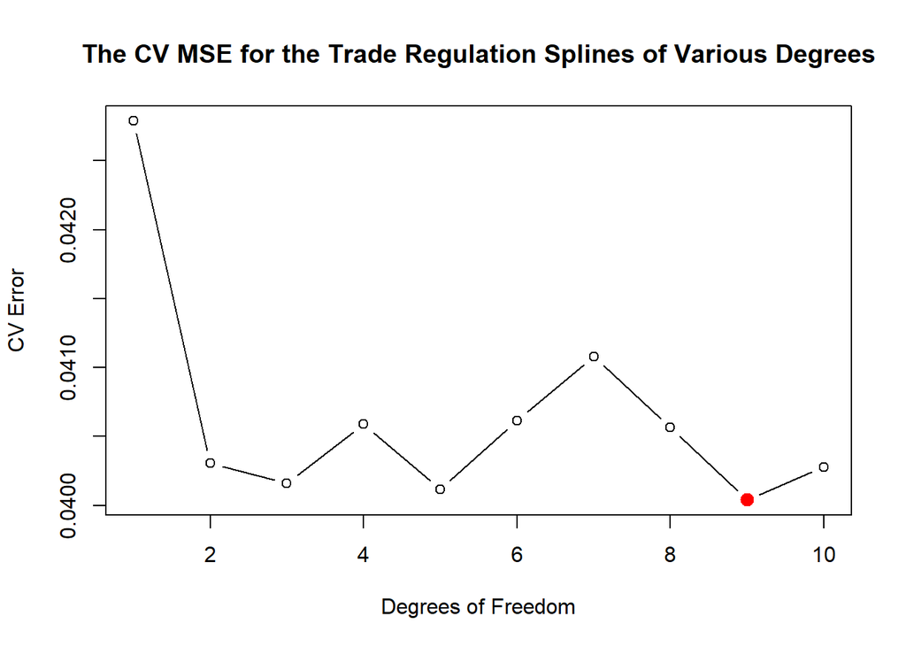

```r
set.seed(111)
max_spline_term = 10
CVerrorSpline_trade_reg = rep(0, max_spline_term)
for (i in 1:max_spline_term) {
  fit = glm(hf_score ~ ns(ef_trade_regulatory, df=i) + . - ef_trade_regulatory, data = hfi_data_combined_train)
  CVerrorSpline_trade_reg[i] <- cv.glm(hfi_data_combined_train, fit, K = 10)$delta[1]
}
plot(CVerrorSpline_trade_reg, main="The CV MSE for the Trade Regulation Splines of Various Degrees",
     xlab = "Degrees of Freedom", ylab = "CV Error", type = "b")
points(which.min(CVerrorSpline_trade_reg), CVerrorSpline_trade_reg[which.min(CVerrorSpline_trade_reg)], col = "red",cex=2,pch =20)
```

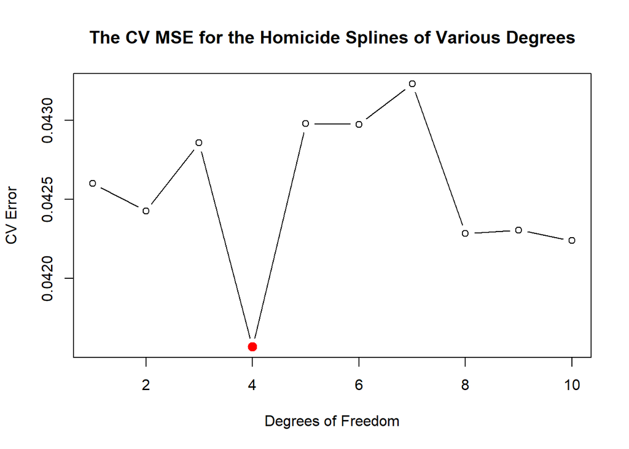

```r
CVerrorSpline_homicide = rep(0, max_spline_term)
for (i in 1:max_spline_term) {
  fit = glm(hf_score ~ ns(pf_ss_homicide, df=i) + . - pf_ss_homicide, data = hfi_data_combined_train)
  CVerrorSpline_homicide[i] <- cv.glm(hfi_data_combined_train, fit, K = 10)$delta[1]
}
plot(CVerrorSpline_homicide, main="The CV MSE for the Homicide Splines of Various Degrees",
     xlab = "Degrees of Freedom", ylab = "CV Error", type = "b")
points(which.min(CVerrorSpline_homicide), CVerrorSpline_homicide[which.min(CVerrorSpline_homicide)], col = "red",cex=2,pch =20)
```

```r
trade_reg_spline_model = glm(hf_score ~ ns(ef_trade_regulatory, df=which.min(CVerrorSpline_trade_reg)) + . - ef_trade_regulatory,
                             data = hfi_data_combined_train)
yhat = predict(trade_reg_spline_model, newdata = hfi_data_combined_test)
trade_reg_spline_model_mse = mean((yhat - hfi_data_combined_test$hf_score)^2)

homicide_spline_model = glm(hf_score ~ ns(ef_trade_regulatory, df=which.min(CVerrorSpline_homicide)) + . - ef_trade_regulatory,
                        data = hfi_data_combined_train)
yhat = predict(homicide_spline_model, newdata = hfi_data_combined_test)
homicide_spline_model_mse = mean((yhat - hfi_data_combined_test$hf_score)^2)


paste("The Mean TSS of the Test Set: ", round(mean_tss_test, 6))
```

```
## [1] "The Mean TSS of the Test Set:  0.882886"
```

```r
paste("MLR Forward Regression with No Polynomial Terms Test MSE: ", round(final_forward_mse, 6))
```

```
## [1] "MLR Forward Regression with No Polynomial Terms Test MSE:  0.042611"
```

```r
paste("MLR with Spline of Term Trade Regulation Test MSE: ", round(trade_reg_spline_model_mse, 6))
```

```
## [1] "MLR with Spline of Term Trade Regulation Test MSE:  0.04055"
```

```r
paste("MLR with Spline of Term Homicide Test MSE: ", round(homicide_spline_model_mse, 6))
```

```
## [1] "MLR with Spline of Term Homicide Test MSE:  0.039919"
```

## 4.3 Generalized Additive Models (GAMs)

We are going to combine the two splines above with a GAM (Generalized Additive Model) to see if improvements can be made.